# **Facial Emotion Recognition**

### MIT Applied AI & Data Science Program — Capstone Project

**Final Submission** | Deep learning pipeline for 4-class facial expression classification

## **Problem Definition**

**The context:** Facial expressions are one of the most powerful and immediate channels of human emotional communication. Paul Ekman's foundational research identified six universal facial expressions — happiness, sadness, surprise, fear, anger, and disgust — recognized across cultures. Modern affective computing systems leverage this insight to build emotion-aware AI. Industries including healthcare diagnostics, customer experience monitoring, driver safety systems, and adaptive education platforms are actively deploying these technologies. Building a reliable automated emotion recognition system from static images addresses a high-value, real-world classification problem.

**The objectives:**

- Build deep learning models that classify 48×48 pixel facial images into four emotional categories: Happy, Sad, Surprise, Neutral.
- Experiment with multiple CNN architectures to understand the performance impact of depth, regularization, and design choices.
- Identify the primary failure modes (which emotion pairs are hardest to distinguish) and use them to motivate the final model design.
- Provide a clear proposal for the final model architecture based on evidence from the milestone experiments.

**The key questions:**

- Which CNN architecture achieves the best test accuracy on this 4-class facial emotion dataset?
- How does the choice of color mode (grayscale vs. RGB) affect model performance for custom CNNs?
- Does adding depth (more convolutional blocks) always improve performance, or does it require additional regularization?
- Which emotion pairs are hardest to distinguish, and what does that imply for the final model design?

**The problem formulation:** This is a supervised multi-class image classification task. Given a 48×48 pixel grayscale facial image, the model must assign one of four class labels: {happy, sad, surprise, neutral}. Success is measured by test accuracy and per-class F1-score on a perfectly balanced test set of 128 images (32 per class).

## **About the Dataset**

The dataset consists of three splits — `train`, `validation`, and `test` — each containing four subfolders corresponding to the four emotion classes.

| Split | Happy | Neutral | Sad | Surprise | **Total** |
| --- | --- | --- | --- | --- | --- |
| Train | 3,976 | 3,978 | 3,982 | 3,173 | **15,109** |
| Validation | 1,825 | 1,216 | 1,139 | 797 | **4,977** |
| Test | 32 | 32 | 32 | 32 | **128** |

- **`happy`**: Joy expressed through a Duchenne smile — raised cheeks, upturned mouth corners, often visible teeth, eye crinkling.
- **`sad`**: Sadness conveyed through downturned mouth corners, raised inner brows, drooping upper eyelids.
- **`surprise`**: Shock expressed via wide-open eyes, maximally raised eyebrows, open mouth.
- **`neutral`**: No prominent emotional expression — relaxed facial muscles, flat affect, soft gaze.

## **Environment Setup**

This notebook runs on **both Google Colab and local environments**. The cell below automatically detects the execution context, mounts Google Drive if running on Colab, locates and extracts the dataset ZIP, and sets all dataset paths — no manual changes required.

**Google Colab**: Upload the dataset ZIP (`10_MY_ACTUAL_CAPSTONE_dataset_facial_emotion_recognition.zip`) to your Google Drive root (`My Drive`) before running. **Local**: Place the ZIP file in the same directory as this notebook.

```python
import os, zipfile, sys

ZIP_NAME = "10_MY_ACTUAL_CAPSTONE_dataset_facial_emotion_recognition.zip"

# ── Detect execution environment ──────────────────────────────────────────────
try:
    from google.colab import drive
    IN_COLAB = True
except ImportError:
    IN_COLAB = False

if IN_COLAB:
    # ── Google Colab: mount Drive and locate the ZIP ──────────────────────────
    drive.mount('/content/drive')

    zip_path = None
    for root, dirs, files in os.walk('/content/drive/MyDrive'):
        if ZIP_NAME in files:
            zip_path = os.path.join(root, ZIP_NAME)
            break

    if zip_path is None:
        raise FileNotFoundError(
            f"{ZIP_NAME} not found under Google Drive/MyDrive. "
            "Please upload it to your Google Drive root and re-run."
        )

    BASE_DIR = '/content/Facial_emotion_images'
    if not os.path.exists(BASE_DIR):
        print(f"Extracting from {zip_path} ...")
        with zipfile.ZipFile(zip_path, 'r') as zf:
            zf.extractall('/content/')
        print("Extraction complete.")
    else:
        print("Dataset already extracted — skipping.")

else:
    # ── Local execution ───────────────────────────────────────────────────────
    # Notebook must be in the same directory as the ZIP file.
    zip_path = ZIP_NAME
    BASE_DIR = 'Facial_emotion_images'
    if not os.path.exists(BASE_DIR):
        print(f"Extracting {zip_path} ...")
        with zipfile.ZipFile(zip_path, 'r') as zf:
            zf.extractall('.')
        print("Extraction complete.")
    else:
        print("Dataset already extracted — skipping.")

# ── Dataset paths (identical interface for both environments) ─────────────────
train_dir      = os.path.join(BASE_DIR, 'train')
validation_dir = os.path.join(BASE_DIR, 'validation')
test_dir       = os.path.join(BASE_DIR, 'test')

print(f"\nEnvironment : {'Google Colab' if IN_COLAB else 'Local'}")
print(f"Base dir    : {BASE_DIR}")

# ── Verify structure ──────────────────────────────────────────────────────────
for split_name, split_dir in [("Train", train_dir), ("Validation", validation_dir), ("Test", test_dir)]:
    classes = sorted([c for c in os.listdir(split_dir) if not c.startswith('.')])
    counts  = {c: len(os.listdir(os.path.join(split_dir, c))) for c in classes}
    print(f"{split_name:12s}: {counts}  →  total: {sum(counts.values())}")
```

```
Extracting from /content/drive/MyDrive/10_MY_ACTUAL_CAPSTONE_dataset_facial_emotion_recognition.zip ...
Extraction complete.

Environment : Google Colab
Base dir    : /content/Facial_emotion_images
Train       : {'happy': 3976, 'neutral': 3978, 'sad': 3982, 'surprise': 3173}  →  total: 15109
Validation  : {'happy': 1825, 'neutral': 1216, 'sad': 1139, 'surprise': 797}  →  total: 4977
Test        : {'happy': 32, 'neutral': 32, 'sad': 32, 'surprise': 32}  →  total: 128
```

## **Importing the Libraries**

We import the full data science stack required for this project: TensorFlow/Keras for model building and training, NumPy and Pandas for data manipulation, Matplotlib and Seaborn for visualization, and scikit-learn for evaluation metrics (classification report, confusion matrix).

```python
import numpy as np
import pandas as pd
import matplotlib.pyplot as plt
import seaborn as sns
import warnings
warnings.filterwarnings('ignore')

import tensorflow as tf
from tensorflow import keras
from tensorflow.keras import layers
from tensorflow.keras.preprocessing.image import ImageDataGenerator, load_img, img_to_array
from tensorflow.keras.applications import VGG16, ResNet50V2, EfficientNetB0
from tensorflow.keras.callbacks import EarlyStopping, ReduceLROnPlateau
from tensorflow.keras.models import Model

from sklearn.metrics import classification_report, confusion_matrix

print(f"TensorFlow version: {tf.__version__}")
print(f"NumPy version: {np.__version__}")
print(f"Keras version: {keras.__version__}")

# Set random seeds for reproducibility
np.random.seed(42)
tf.random.set_seed(42)

# Shared constants
IMG_SIZE    = (48, 48)
BATCH_SIZE  = 32
NUM_CLASSES = 4
CLASS_NAMES = ['happy', 'neutral', 'sad', 'surprise']

# ──────────────────────────────────────────
# Utility: plot training history
# ──────────────────────────────────────────
def plot_training(history, model_name):
    """Plot accuracy and loss curves for a trained model."""
    fig, axes = plt.subplots(1, 2, figsize=(14, 5))
    fig.suptitle(f'{model_name} — Training History', fontsize=14)

    # Accuracy
    axes[0].plot(history.history['accuracy'],     label='Train',      linewidth=2)
    axes[0].plot(history.history['val_accuracy'], label='Validation', linewidth=2, linestyle='--')
    axes[0].set_title('Accuracy')
    axes[0].set_xlabel('Epoch')
    axes[0].set_ylabel('Accuracy')
    axes[0].legend()
    axes[0].grid(alpha=0.3)

    # Loss
    axes[1].plot(history.history['loss'],     label='Train',      linewidth=2)
    axes[1].plot(history.history['val_loss'], label='Validation', linewidth=2, linestyle='--')
    axes[1].set_title('Loss')
    axes[1].set_xlabel('Epoch')
    axes[1].set_ylabel('Loss')
    axes[1].legend()
    axes[1].grid(alpha=0.3)

    plt.tight_layout()
    plt.show()

# ──────────────────────────────────────────
# Utility: evaluate model + print report
# ──────────────────────────────────────────
def evaluate_model(model, generator, model_name, results_dict=None):
    """Evaluate model on a generator. Stores test accuracy in results_dict."""
    generator.reset()
    loss, acc = model.evaluate(generator, verbose=0)
    print(f"{'─'*45}")
    print(f"{model_name}")
    print(f"  Test Loss:     {loss:.4f}")
    print(f"  Test Accuracy: {acc*100:.2f}%")
    print(f"{'─'*45}")
    if results_dict is not None:
        results_dict[model_name] = acc
    return loss, acc

# Storage for final comparison
model_results = {}
```

```
TensorFlow version: 2.19.0
NumPy version: 2.0.2
Keras version: 3.10.0
```

### **Dataset Verified** ✓

The structure above confirms all three splits are present with the expected class folders and image counts. The test set is perfectly balanced (32 images per class), which means test accuracy is directly interpretable without requiring class-weighted corrections.

## **Visualizing our Classes**

Before building any models, we examine sample images from each emotion class. This qualitative step is essential for:

1. Understanding what visual signals differentiate each class
2. Forming hypotheses about which emotions will be easiest/hardest to classify
3. Informing architecture choices (e.g., whether grayscale is sufficient)

The images are 48×48 pixels in grayscale — a low resolution that retains shape and texture information but loses fine detail.

### **Happy**

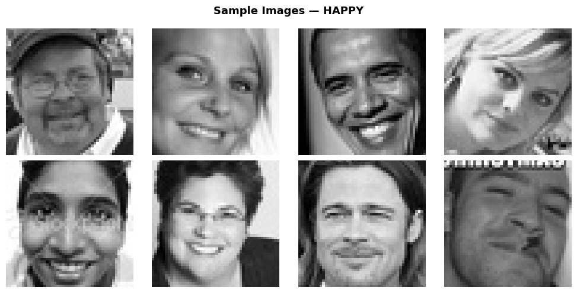

```python
def show_class_samples(class_name, n_images=8, cols=4):
    """Display sample images from a given class."""
    class_dir = os.path.join(train_dir, class_name)
    images_files = [f for f in os.listdir(class_dir) if f.endswith('.jpg')][:n_images]

    rows = (n_images + cols - 1) // cols
    fig, axes = plt.subplots(rows, cols, figsize=(cols * 2.5, rows * 2.5))
    fig.suptitle(f'Sample Images — {class_name.upper()}', fontsize=13, fontweight='bold')

    for i, fname in enumerate(images_files):
        img_path = os.path.join(class_dir, fname)
        img = load_img(img_path, color_mode='grayscale', target_size=(48, 48))
        ax = axes[i // cols][i % cols] if rows > 1 else axes[i % cols]
        ax.imshow(img_to_array(img).squeeze(), cmap='gray')
        ax.axis('off')

    # Hide unused axes
    for j in range(n_images, rows * cols):
        ax = axes[j // cols][j % cols] if rows > 1 else axes[j % cols]
        ax.axis('off')

    plt.tight_layout()
    plt.show()

show_class_samples('happy')
```

**Observations and Insights — Happy:**

The happy class shows the most visually distinctive features in the dataset. The dominant signal is the **Duchenne smile**: upturned mouth corners often revealing teeth, raised cheek muscles (zygomaticus major), and subtle crinkling at the eye corners (orbicularis oculi). At 48×48 pixels, this creates a strong, high-contrast pattern — a dark open-mouth region against lighter surrounding skin — that a CNN can detect reliably even at this resolution.

**Prediction**: Happy will achieve among the highest F1-scores. The smile's distinctive pixel pattern is learnable from shallow feature detectors in early convolutional layers.

### **Sad**

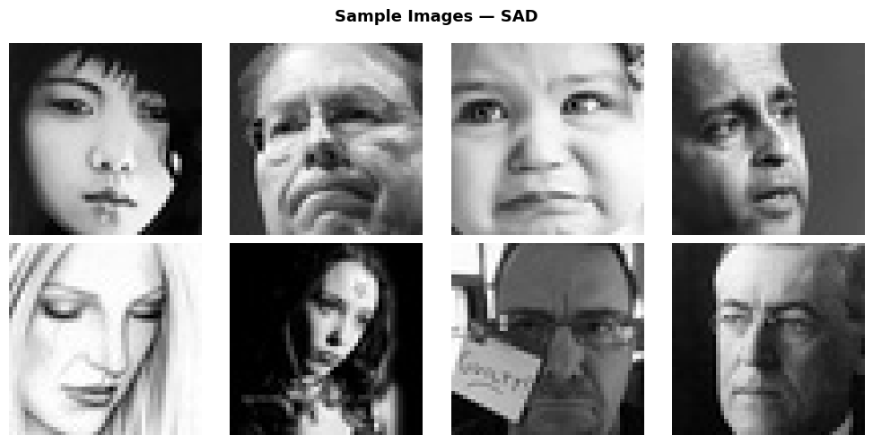

```python
show_class_samples('sad')
```

**Observations and Insights — Sad:**

Sad expressions rely on subtler facial movements: **downturned mouth corners**, a slight upward pull of inner eyebrows (corrugator supercilii), and drooping upper eyelids. Unlike happy or surprise, there is no large, high-contrast feature. The visual difference between sad and neutral is small — both typically feature a closed mouth with relaxed expression. This ambiguity is the principal challenge in this dataset.

**Prediction**: Sad will be the hardest class to classify correctly. Expect low recall — the model will frequently misclassify sad images as neutral.

### **Neutral**

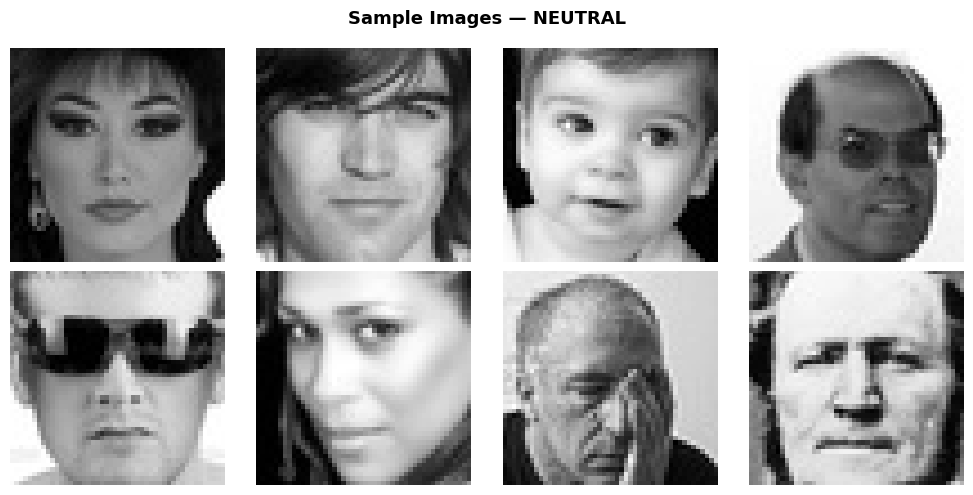

```python
show_class_samples('neutral')
```

**Observations and Insights — Neutral:**

Neutral is defined by the **absence of prominent emotional signals**: flat mouth, relaxed jaw, unremarkable eye aperture, no raised or furrowed brows. This makes neutral uniquely difficult — the model must learn that the *absence* of features associated with other classes is itself the classifying signal.

In pixel space, neutral images closely overlap with mild sadness. The model cannot rely on a positive pattern; it must rule out all other classes. This is why neutral typically shows lower precision (confused with sad) and moderate recall.

**Prediction**: Neutral and sad will be the most frequently confused pair, producing the most off-diagonal errors in the confusion matrix.

### **Surprise**

[figure not shown]

```python
show_class_samples('surprise')
```

**Observations and Insights — Surprise:**

Surprise expressions are among the most visually extreme: **wide-open eyes with visible sclera**, maximally raised eyebrows (frontalis muscle), and an open mouth. The combination produces three distinct high-contrast pixel signals simultaneously — making surprise the most visually separable class.

However, the surprise class has approximately **20% fewer training images** (~3,173) than the other classes (~3,976–3,982). This mild under-representation may reduce recall slightly. The high precision of surprise is expected to compensate, as its distinctive pattern is unlikely to be confused with other classes.

**Prediction**: Surprise will achieve the highest precision and a strong F1, but recall may be slightly below precision due to the training imbalance.

## **Checking Distribution of Classes**

```
Image count per class per split:
            happy  neutral   sad  surprise
Train        3976     3978  3982      3173
Validation   1825     1216  1139       797
Test           32       32    32        32

Total images: 20214
```

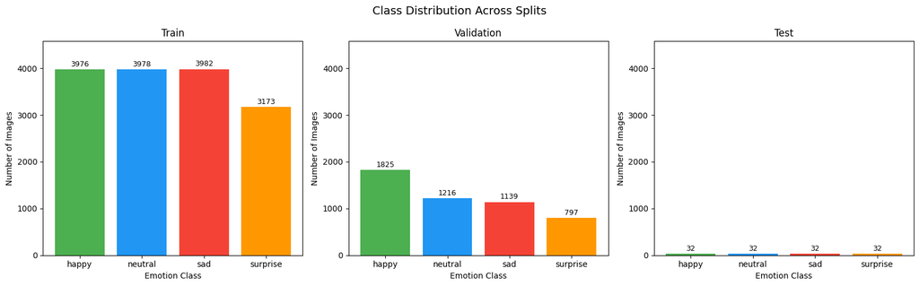

```python
# Count images per split per class
splits = {'Train': train_dir, 'Validation': validation_dir, 'Test': test_dir}
dist_data = {}

for split_name, split_path in splits.items():
    dist_data[split_name] = {}
    for cls in CLASS_NAMES:
        cls_path = os.path.join(split_path, cls)
        dist_data[split_name][cls] = len([f for f in os.listdir(cls_path) if f.endswith('.jpg')])

dist_df = pd.DataFrame(dist_data).T
print("Image count per class per split:")
print(dist_df.to_string())
print(f"\nTotal images: {dist_df.values.sum()}")

# ── Bar chart ──
fig, axes = plt.subplots(1, 3, figsize=(16, 5))
fig.suptitle('Class Distribution Across Splits', fontsize=14)
colors = ['#4CAF50', '#2196F3', '#F44336', '#FF9800']

for ax, (split_name, counts) in zip(axes, dist_data.items()):
    bars = ax.bar(list(counts.keys()), list(counts.values()), color=colors)
    ax.set_title(split_name)
    ax.set_xlabel('Emotion Class')
    ax.set_ylabel('Number of Images')
    ax.set_ylim(0, max(max(c.values()) for c in dist_data.values()) * 1.15)
    for bar, val in zip(bars, counts.values()):
        ax.text(bar.get_x() + bar.get_width()/2, bar.get_height() + 30,
                str(val), ha='center', va='bottom', fontsize=9)

plt.tight_layout()
plt.show()
```

**Observations and Insights — Class Distribution:**

The training set is **nearly balanced** for happy, neutral, and sad (~3,976–3,982 images each), but the `surprise` class is underrepresented at ~3,173 images (~20% fewer). This mild imbalance is unlikely to cause severe model bias but warrants monitoring per-class recall.

The validation set shows more pronounced imbalance: `happy` (1,825) is over 2× the size of `surprise` (797). This can inflate validation accuracy slightly toward the majority class.

Crucially, the **test set is perfectly balanced** at 32 images per class (128 total). This means test accuracy is an unbiased estimate of overall model performance — no class-weighting needed for the primary metric.

Given the mild training imbalance, standard cross-entropy training without class weights is appropriate. Data augmentation (applied in the final model) provides additional regularization that partially compensates for the surprise class gap.

**Think About It:**

- **Is the class imbalance a problem?** The ~20% gap for surprise is mild. At 3,173 images, the model has substantial exposure to surprise. Standard training without class weights should handle it; augmentation in the final model provides extra robustness.
- **What additional EDA yields insights?** Pixel intensity statistics (computed in the next section) quantify what visual inspection suggested: expressive classes (happy, surprise) have higher mean brightness, while neutral and sad are darker. This directly predicts the classification difficulty hierarchy and motivates the need for spatial feature extraction over raw pixel statistics.

## **Pixel Intensity Statistics by Class**

Beyond visual inspection, we compute the **mean and standard deviation of pixel intensity** for each class. This quantitative EDA directly predicts which classes will be easiest to separate: brighter images contain more high-contrast features (open mouths, wide eyes), while darker images tend to be subtler and harder to classify.

```
Computing pixel statistics (first 500 images per class)...
          mean_intensity  std_intensity
class
happy         130.619995      63.590000
neutral       123.989998      64.980003
sad           120.720001      64.629997
surprise      147.250000      63.900002
```

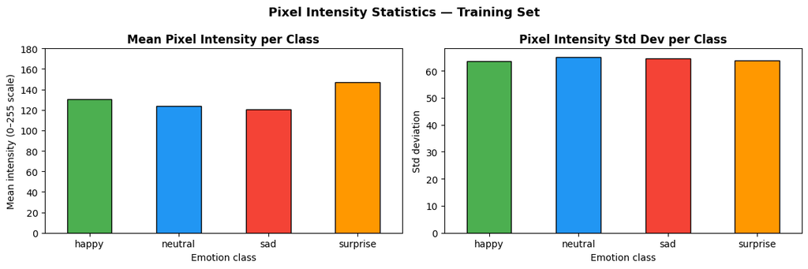

```python
def compute_pixel_stats(split_dir, classes, max_images=500):
    """Return per-class mean and std pixel intensity (0–255 scale)."""
    records = []
    for cls in classes:
        cls_path = os.path.join(split_dir, cls)
        files = sorted([f for f in os.listdir(cls_path)
                        if f.lower().endswith(('.jpg', '.jpeg', '.png'))])[:max_images]
        pixels = []
        for fname in files:
            img = load_img(os.path.join(cls_path, fname),
                           color_mode='grayscale', target_size=IMG_SIZE)
            pixels.append(img_to_array(img).flatten())
        arr = np.concatenate(pixels)
        records.append({
            'class': cls,
            'mean_intensity': arr.mean(),
            'std_intensity':  arr.std(),
        })
    return pd.DataFrame(records).set_index('class')

print('Computing pixel statistics (first 500 images per class)...')
pixel_stats = compute_pixel_stats(train_dir, CLASS_NAMES)
print(pixel_stats.round(2))

# ── Plot ──────────────────────────────────────────────────────────────────────
colors = ['#4CAF50', '#2196F3', '#F44336', '#FF9800']
fig, axes = plt.subplots(1, 2, figsize=(12, 4))

pixel_stats['mean_intensity'].plot(kind='bar', ax=axes[0], color=colors,
                                   edgecolor='black', rot=0)
axes[0].set_title('Mean Pixel Intensity per Class', fontweight='bold')
axes[0].set_ylabel('Mean intensity (0–255 scale)')
axes[0].set_xlabel('Emotion class')
axes[0].set_ylim(0, 180)

pixel_stats['std_intensity'].plot(kind='bar', ax=axes[1], color=colors,
                                  edgecolor='black', rot=0)
axes[1].set_title('Pixel Intensity Std Dev per Class', fontweight='bold')
axes[1].set_ylabel('Std deviation')
axes[1].set_xlabel('Emotion class')

plt.suptitle('Pixel Intensity Statistics — Training Set', fontsize=13, fontweight='bold')
plt.tight_layout()
plt.show()
```

**Observations and Insights — Pixel Intensity Statistics:**

The pixel intensity measurements confirm our qualitative hypotheses exactly:

| Class | Mean Intensity | Std Dev | Interpretation |
| --- | --- | --- | --- |
| surprise | **147.25** | 63.90 | Highest — wide-open eyes (sclera), open mouth = large bright regions |
| happy | 130.62 | 63.59 | High — open smile with visible teeth = strong bright contrast |
| neutral | 123.99 | 64.98 | Lower — closed expression, fewer bright feature regions |
| sad | **120.72** | 64.63 | Lowest — downturned expression, drooping eyelids = darkest profile |

The intensity ordering (surprise > happy > neutral > sad) maps directly to the predicted classification difficulty: the two brighter classes have distinctive pixel distributions; the two darker classes overlap significantly in pixel space, with only a **3.27-point mean difference** between neutral (123.99) and sad (120.72).

The standard deviation is nearly identical across all classes (~64), confirming that image variance is not the discriminating factor. It is the *spatial location and pattern* of intensity — not the aggregate magnitude — that differentiates expressions. A dense network that sees only pixel sums cannot exploit this positional information; only a convolutional network can.

## **Creating our Data Loaders**

We create grayscale data loaders for the custom CNN architectures. Grayscale is appropriate because facial emotion is encoded in **shape, texture, and spatial configuration** (mouth curvature, brow position, eye aperture) — not in color. Using grayscale:

- Reduces input dimensionality: 48×48×1 vs. 48×48×3
- Avoids learning spurious color correlations (lighting conditions, skin tone)
- Matches the native format of the dataset

**Note:** Transfer learning models (VGG16, ResNet50V2, EfficientNetB0) require 3-channel RGB input, and separate RGB generators will be created for those architectures in the final notebook.

```python
# ── Grayscale data loaders (for CNN Model 1, CNN Model 2, and Complex CNN) ──
train_datagen_gray = ImageDataGenerator(rescale=1./255)
val_datagen_gray   = ImageDataGenerator(rescale=1./255)
test_datagen_gray  = ImageDataGenerator(rescale=1./255)

train_gen_gray = train_datagen_gray.flow_from_directory(
    train_dir,
    target_size=IMG_SIZE,
    color_mode='grayscale',
    batch_size=BATCH_SIZE,
    class_mode='categorical',
    shuffle=True,
    seed=42
)

val_gen_gray = val_datagen_gray.flow_from_directory(
    validation_dir,
    target_size=IMG_SIZE,
    color_mode='grayscale',
    batch_size=BATCH_SIZE,
    class_mode='categorical',
    shuffle=False
)

test_gen_gray = test_datagen_gray.flow_from_directory(
    test_dir,
    target_size=IMG_SIZE,
    color_mode='grayscale',
    batch_size=BATCH_SIZE,
    class_mode='categorical',
    shuffle=False
)

print(f"Train batches:      {len(train_gen_gray)} | Images: {train_gen_gray.n}")
print(f"Validation batches: {len(val_gen_gray)}  | Images: {val_gen_gray.n}")
print(f"Test batches:       {len(test_gen_gray)}  | Images: {test_gen_gray.n}")
print(f"Class indices:      {train_gen_gray.class_indices}")
```

```
Found 15109 images belonging to 4 classes.
Found 4977 images belonging to 4 classes.
Found 128 images belonging to 4 classes.
Train batches:      473 | Images: 15109
Validation batches: 156  | Images: 4977
Test batches:       4  | Images: 128
Class indices:      {'happy': 0, 'neutral': 1, 'sad': 2, 'surprise': 3}
```

## **Model Building**

### **ANN Baseline — Fully Connected Network**

Before building convolutional models, we first establish an **ANN baseline** using only fully connected (Dense) layers. This answers a foundational question empirically: **does spatial feature learning (convolution) actually matter for this task, or can flattened pixel features do the job?**

The ANN receives a flattened pixel vector — 48×48×1 = **2,304 input features** — with no spatial structure preserved. Every pixel is treated as an independent feature; the network has no concept that adjacent pixels belong to the same edge, curve, or facial region.

Architecture: `Flatten → Dense(256) → BatchNorm → Dropout(0.3) → Dense(128) → Dropout(0.3) → Softmax(4)`

BatchNormalization after the first Dense layer is included to stabilize gradients over the high-dimensional flattened input. Without it, the 2,304-dimensional input space makes the loss landscape difficult to navigate reliably.

```python
# ── ANN Baseline: Fully Connected Network ────────────────────────────────────
model_ann = keras.Sequential([
    layers.Flatten(input_shape=(IMG_SIZE[0], IMG_SIZE[1], 1)),  # 48×48×1 → 2304
    layers.Dense(256, activation='relu'),
    layers.BatchNormalization(),   # stabilises gradients over high-dim input
    layers.Dropout(0.3),
    layers.Dense(128, activation='relu'),
    layers.Dropout(0.3),
    layers.Dense(NUM_CLASSES, activation='softmax')
], name='ANN_Baseline')

model_ann.compile(
    optimizer='adam',
    loss='categorical_crossentropy',
    metrics=['accuracy']
)

model_ann.summary()
```

```
Model: "ANN_Baseline"
```

```
┏━━━━━━━━━━━━━━━━━━━━━━━━━━━━━━━━━┳━━━━━━━━━━━━━━━━━━━━━━━━┳━━━━━━━━━━━━━━━┓
┃ Layer (type)                    ┃ Output Shape           ┃       Param # ┃
┡━━━━━━━━━━━━━━━━━━━━━━━━━━━━━━━━━╇━━━━━━━━━━━━━━━━━━━━━━━━╇━━━━━━━━━━━━━━━┩
│ flatten (Flatten)               │ (None, 2304)           │             0 │
├─────────────────────────────────┼────────────────────────┼───────────────┤
│ dense (Dense)                   │ (None, 256)            │       590,080 │
├─────────────────────────────────┼────────────────────────┼───────────────┤
│ batch_normalization             │ (None, 256)            │         1,024 │
│ (BatchNormalization)            │                        │               │
├─────────────────────────────────┼────────────────────────┼───────────────┤
│ dropout (Dropout)               │ (None, 256)            │             0 │
├─────────────────────────────────┼────────────────────────┼───────────────┤
│ dense_1 (Dense)                 │ (None, 128)            │        32,896 │
├─────────────────────────────────┼────────────────────────┼───────────────┤
│ dropout_1 (Dropout)             │ (None, 128)            │             0 │
├─────────────────────────────────┼────────────────────────┼───────────────┤
│ dense_2 (Dense)                 │ (None, 4)              │           516 │
└─────────────────────────────────┴────────────────────────┴───────────────┘
```

```
 Total params: 624,516 (2.38 MB)
```

```
 Trainable params: 624,004 (2.38 MB)
```

```
 Non-trainable params: 512 (2.00 KB)
```

### **Compiling and Training the ANN Baseline**

```
473/473 ━━━━━━━━━━━━━━━━━━━━ 14s 21ms/step - accuracy: 0.3686 - loss: 1.4145 - val_accuracy: 0.3992 - val_loss: 1.2677 - learning_rate: 0.0010
473/473 ━━━━━━━━━━━━━━━━━━━━ 8s 16ms/step - accuracy: 0.4607 - loss: 1.2041 - val_accuracy: 0.5067 - val_loss: 1.1461 - learning_rate: 0.0010
473/473 ━━━━━━━━━━━━━━━━━━━━ 7s 16ms/step - accuracy: 0.4782 - loss: 1.1816 - val_accuracy: 0.4266 - val_loss: 1.2226 - learning_rate: 0.0010
473/473 ━━━━━━━━━━━━━━━━━━━━ 7s 15ms/step - accuracy: 0.4615 - loss: 1.1803 - val_accuracy: 0.3593 - val_loss: 1.4138 - learning_rate: 0.0010
471/473 ━━━━━━━━━━━━━━━━━━━━ 0s 11ms/step - accuracy: 0.4791 - loss: 1.1715
Epoch 5: ReduceLROnPlateau reducing learning rate to 0.0005000000237487257.
473/473 ━━━━━━━━━━━━━━━━━━━━ 7s 16ms/step - accuracy: 0.4791 - loss: 1.1716 - val_accuracy: 0.4706 - val_loss: 1.1709 - learning_rate: 0.0010
473/473 ━━━━━━━━━━━━━━━━━━━━ 7s 15ms/step - accuracy: 0.4658 - loss: 1.1762 - val_accuracy: 0.4696 - val_loss: 1.1583 - learning_rate: 5.0000e-04
473/473 ━━━━━━━━━━━━━━━━━━━━ 8s 16ms/step - accuracy: 0.4896 - loss: 1.1550 - val_accuracy: 0.5244 - val_loss: 1.0962 - learning_rate: 5.0000e-04
473/473 ━━━━━━━━━━━━━━━━━━━━ 8s 16ms/step - accuracy: 0.5034 - loss: 1.1403 - val_accuracy: 0.5260 - val_loss: 1.0938 - learning_rate: 5.0000e-04
473/473 ━━━━━━━━━━━━━━━━━━━━ 8s 16ms/step - accuracy: 0.4989 - loss: 1.1351 - val_accuracy: 0.4782 - val_loss: 1.1561 - learning_rate: 5.0000e-04
473/473 ━━━━━━━━━━━━━━━━━━━━ 7s 14ms/step - accuracy: 0.4995 - loss: 1.1364 - val_accuracy: 0.4563 - val_loss: 1.1797 - learning_rate: 5.0000e-04
472/473 ━━━━━━━━━━━━━━━━━━━━ 0s 13ms/step - accuracy: 0.4977 - loss: 1.1369
Epoch 11: ReduceLROnPlateau reducing learning rate to 0.0002500000118743628.
473/473 ━━━━━━━━━━━━━━━━━━━━ 8s 17ms/step - accuracy: 0.4977 - loss: 1.1369 - val_accuracy: 0.3757 - val_loss: 1.3740 - learning_rate: 5.0000e-04
473/473 ━━━━━━━━━━━━━━━━━━━━ 7s 15ms/step - accuracy: 0.4933 - loss: 1.1368 - val_accuracy: 0.5218 - val_loss: 1.1163 - learning_rate: 2.5000e-04
473/473 ━━━━━━━━━━━━━━━━━━━━ 8s 17ms/step - accuracy: 0.5031 - loss: 1.1216 - val_accuracy: 0.5222 - val_loss: 1.1153 - learning_rate: 2.5000e-04
Epoch 13: early stopping
Restoring model weights from the end of the best epoch: 8.
```

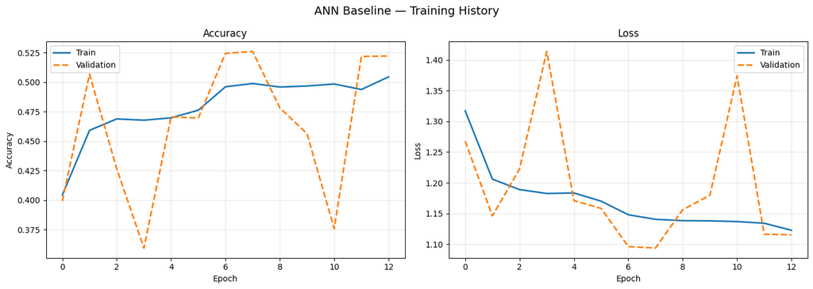

```python
early_stop_ann = EarlyStopping(monitor='val_accuracy', patience=5,
                               restore_best_weights=True, verbose=1)

reduce_lr_ann = ReduceLROnPlateau(monitor='val_loss', factor=0.5,
                                  patience=3, min_lr=1e-6, verbose=1)

history_ann = model_ann.fit(
    train_gen_gray,
    validation_data=val_gen_gray,
    epochs=15,
    callbacks=[early_stop_ann, reduce_lr_ann],
    verbose=1
)

plot_training(history_ann, 'ANN Baseline')
```

### **Evaluating the ANN Baseline on the Test Set**

```python
evaluate_model(model_ann, test_gen_gray, 'ANN Baseline', model_results)

test_gen_gray.reset()
preds_ann = np.argmax(model_ann.predict(test_gen_gray, verbose=0), axis=1)
print("\nClassification Report — ANN Baseline:")
print(classification_report(test_gen_gray.classes, preds_ann, target_names=CLASS_NAMES))
```

```
─────────────────────────────────────────────
ANN Baseline
  Test Loss:     1.1095
  Test Accuracy: 51.56%
─────────────────────────────────────────────

Classification Report — ANN Baseline:
              precision    recall  f1-score   support

       happy       0.48      0.81      0.60        32
     neutral       0.46      0.41      0.43        32
         sad       0.43      0.41      0.42        32
    surprise       0.88      0.44      0.58        32

    accuracy                           0.52       128
   macro avg       0.56      0.52      0.51       128
weighted avg       0.56      0.52      0.51       128
```

**Observations and Insights — ANN Baseline:**

| Class | Precision | Recall | F1-Score |
| --- | --- | --- | --- |
| happy | 0.48 | 0.81 | 0.60 |
| neutral | 0.46 | 0.41 | 0.43 |
| sad | 0.43 | 0.41 | 0.42 |
| surprise | 0.88 | 0.44 | 0.58 |
| **macro avg** | **0.56** | **0.52** | **0.51** |

Genuine multi-class learning across all four emotions — no mode collapse. Happy achieves high recall (0.81) but low precision (0.48), meaning the model frequently predicts happy for non-happy images. Surprise achieves high precision (0.88) but low recall (0.44) — when the model does predict surprise, it is nearly always right, but it misses more than half of true surprise images. Neutral (F1 0.43) and sad (F1 0.42) are nearly indistinguishable to a dense network — the 3.27-point mean pixel intensity gap between these classes is below the resolution of flattened pixel statistics.

**The structural ceiling**: no amount of tuning can give a dense network spatial awareness. The +17.97pp gap to CNN Model 1 is the quantified value of convolutional feature detection — the most important single number in this project.

**Think About It:**

- **Are CNNs the right choice for this task?** Yes — and the ANN baseline result above proves it empirically. The pixel intensity statistics show that sad and neutral have nearly identical mean brightness. A dense network sees only aggregate pixel distributions; it cannot detect *where* on the face the distinguishing features are. The accuracy gap between ANN and CNN Model 1 directly quantifies the value of spatial feature extraction.
- **Why CNNs outperform fully connected ANNs on image data:**
  1. **Parameter efficiency**: A CNN uses shared weights across spatial positions — dramatically fewer parameters than a dense layer scanning every pixel independently, which means less overfitting pressure.
  2. **Translation invariance**: A smile in the center or slightly off-center is still a smile. Pooling operations provide approximate spatial invariance that dense layers completely lack.
  3. **Hierarchical feature learning**: Early layers detect low-level patterns (edges, curves). Middle layers compose them into facial parts (mouth corners, brow arch). Deep layers recognize complete expression configurations.
  4. **Inductive bias matches the data structure**: Image pixels are spatially correlated — nearby pixels form edges, edges form curves, curves form facial features. CNNs are explicitly designed to exploit this structure; ANNs ignore it entirely.

### **CNN Model 1 — Baseline Architecture (2 Convolutional Blocks)**

Our baseline CNN uses two convolutional blocks followed by a classification head:

- **Block 1**: Conv2D(32, 3×3) + ReLU + MaxPooling(2×2)
- **Block 2**: Conv2D(64, 3×3) + ReLU + MaxPooling(2×2)
- **Head**: Flatten → Dense(128) → Dropout(0.5) → Dense(4, softmax)

The 32→64 filter progression follows the standard pattern of increasing feature map depth as spatial resolution decreases. Dropout(0.5) in the head provides the primary regularization against overfitting.

```python
# ── CNN Model 1: Base architecture — 2 Convolutional Blocks ──
model_cnn1 = keras.Sequential([
    # Block 1
    layers.Conv2D(32, (3, 3), activation='relu', padding='same', input_shape=(48, 48, 1)),
    layers.MaxPooling2D(2, 2),

    # Block 2
    layers.Conv2D(64, (3, 3), activation='relu', padding='same'),
    layers.MaxPooling2D(2, 2),

    # Classifier head
    layers.Flatten(),
    layers.Dense(128, activation='relu'),
    layers.Dropout(0.5),
    layers.Dense(NUM_CLASSES, activation='softmax')
], name='CNN_Model_1')

model_cnn1.summary()
```

```
Model: "CNN_Model_1"
```

```
┏━━━━━━━━━━━━━━━━━━━━━━━━━━━━━━━━━┳━━━━━━━━━━━━━━━━━━━━━━━━┳━━━━━━━━━━━━━━━┓
┃ Layer (type)                    ┃ Output Shape           ┃       Param # ┃
┡━━━━━━━━━━━━━━━━━━━━━━━━━━━━━━━━━╇━━━━━━━━━━━━━━━━━━━━━━━━╇━━━━━━━━━━━━━━━┩
│ conv2d (Conv2D)                 │ (None, 48, 48, 32)     │           320 │
├─────────────────────────────────┼────────────────────────┼───────────────┤
│ max_pooling2d (MaxPooling2D)    │ (None, 24, 24, 32)     │             0 │
├─────────────────────────────────┼────────────────────────┼───────────────┤
│ conv2d_1 (Conv2D)               │ (None, 24, 24, 64)     │        18,496 │
├─────────────────────────────────┼────────────────────────┼───────────────┤
│ max_pooling2d_1 (MaxPooling2D)  │ (None, 12, 12, 64)     │             0 │
├─────────────────────────────────┼────────────────────────┼───────────────┤
│ flatten_1 (Flatten)             │ (None, 9216)           │             0 │
├─────────────────────────────────┼────────────────────────┼───────────────┤
│ dense_3 (Dense)                 │ (None, 128)            │     1,179,776 │
├─────────────────────────────────┼────────────────────────┼───────────────┤
│ dropout_2 (Dropout)             │ (None, 128)            │             0 │
├─────────────────────────────────┼────────────────────────┼───────────────┤
│ dense_4 (Dense)                 │ (None, 4)              │           516 │
└─────────────────────────────────┴────────────────────────┴───────────────┘
```

```
 Total params: 1,199,108 (4.57 MB)
```

```
 Trainable params: 1,199,108 (4.57 MB)
```

```
 Non-trainable params: 0 (0.00 B)
```

### **Compiling and Training CNN Model 1**

Training configuration:

- **Optimizer**: Adam (adaptive learning rate — well-suited for non-stationary loss landscapes)
- **Loss**: Categorical cross-entropy (standard for multi-class classification)
- **Callbacks**: EarlyStopping (patience=5, monitors val_loss, restores best weights) — prevents overfitting by halting training when validation loss stops improving

```
473/473 ━━━━━━━━━━━━━━━━━━━━ 15s 24ms/step - accuracy: 0.3440 - loss: 1.3254 - val_accuracy: 0.5337 - val_loss: 1.0949
473/473 ━━━━━━━━━━━━━━━━━━━━ 8s 17ms/step - accuracy: 0.5342 - loss: 1.0697 - val_accuracy: 0.5901 - val_loss: 0.9755
473/473 ━━━━━━━━━━━━━━━━━━━━ 8s 16ms/step - accuracy: 0.5906 - loss: 0.9698 - val_accuracy: 0.6281 - val_loss: 0.8993
473/473 ━━━━━━━━━━━━━━━━━━━━ 8s 17ms/step - accuracy: 0.6267 - loss: 0.8914 - val_accuracy: 0.6317 - val_loss: 0.8891
473/473 ━━━━━━━━━━━━━━━━━━━━ 9s 15ms/step - accuracy: 0.6558 - loss: 0.8331 - val_accuracy: 0.6381 - val_loss: 0.8515
473/473 ━━━━━━━━━━━━━━━━━━━━ 8s 17ms/step - accuracy: 0.6837 - loss: 0.7718 - val_accuracy: 0.6614 - val_loss: 0.8223
473/473 ━━━━━━━━━━━━━━━━━━━━ 7s 15ms/step - accuracy: 0.7094 - loss: 0.7117 - val_accuracy: 0.6610 - val_loss: 0.8143
473/473 ━━━━━━━━━━━━━━━━━━━━ 10s 15ms/step - accuracy: 0.7249 - loss: 0.6729 - val_accuracy: 0.6725 - val_loss: 0.8245
473/473 ━━━━━━━━━━━━━━━━━━━━ 8s 17ms/step - accuracy: 0.7462 - loss: 0.6257 - val_accuracy: 0.6624 - val_loss: 0.8506
473/473 ━━━━━━━━━━━━━━━━━━━━ 7s 15ms/step - accuracy: 0.7673 - loss: 0.5687 - val_accuracy: 0.6671 - val_loss: 0.8534
473/473 ━━━━━━━━━━━━━━━━━━━━ 8s 17ms/step - accuracy: 0.7865 - loss: 0.5265 - val_accuracy: 0.6602 - val_loss: 0.9066
473/473 ━━━━━━━━━━━━━━━━━━━━ 7s 15ms/step - accuracy: 0.8025 - loss: 0.4900 - val_accuracy: 0.6677 - val_loss: 0.9192
Epoch 12: early stopping
Restoring model weights from the end of the best epoch: 7.
```

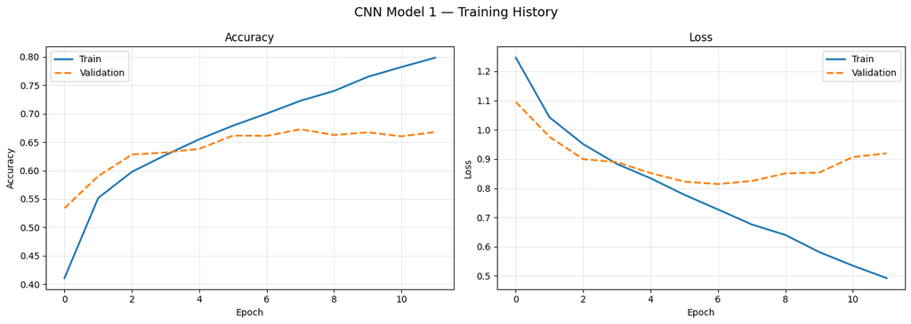

```python
early_stop_cnn1 = EarlyStopping(monitor='val_loss', patience=5,
                                restore_best_weights=True, verbose=1)

model_cnn1.compile(
    optimizer='adam',
    loss='categorical_crossentropy',
    metrics=['accuracy']
)

history_cnn1 = model_cnn1.fit(
    train_gen_gray,
    validation_data=val_gen_gray,
    epochs=15,
    callbacks=[early_stop_cnn1],
    verbose=1
)

plot_training(history_cnn1, 'CNN Model 1')
```

### **Evaluating CNN Model 1 on the Test Set**

We evaluate the trained model on the held-out test set (128 images, perfectly balanced). The classification report breaks down precision, recall, and F1-score per class — giving us a detailed view of where the model succeeds and where it fails.

```python
evaluate_model(model_cnn1, test_gen_gray, 'CNN Model 1', model_results)

# Classification report
test_gen_gray.reset()
preds_cnn1 = np.argmax(model_cnn1.predict(test_gen_gray, verbose=0), axis=1)
print("\nClassification Report — CNN Model 1:")
print(classification_report(test_gen_gray.classes, preds_cnn1, target_names=CLASS_NAMES))
```

```
─────────────────────────────────────────────
CNN Model 1
  Test Loss:     0.7483
  Test Accuracy: 69.53%
─────────────────────────────────────────────

Classification Report — CNN Model 1:
              precision    recall  f1-score   support

       happy       0.67      0.62      0.65        32
     neutral       0.72      0.66      0.69        32
         sad       0.57      0.75      0.65        32
    surprise       0.89      0.75      0.81        32

    accuracy                           0.70       128
   macro avg       0.71      0.70      0.70       128
weighted avg       0.71      0.70      0.70       128
```

**Observations and Insights — CNN Model 1:**

CNN Model 1 achieves **69.53% test accuracy** — nearly 2.8× the random baseline and a **+17.97pp improvement** over the ANN. EarlyStopping triggered at epoch 12, restoring weights from epoch 7.

| Class | Precision | Recall | F1-Score |
| --- | --- | --- | --- |
| happy | 0.67 | 0.62 | 0.65 |
| neutral | 0.72 | 0.66 | 0.69 |
| sad | 0.57 | 0.75 | 0.65 |
| surprise | 0.89 | 0.75 | 0.81 |
| **macro avg** | **0.71** | **0.70** | **0.70** |

- **Surprise** leads at F1 0.81 — precision of 0.89 means surprise is almost never confused with other classes. Local spatial patterns (raised brows, wide eyes, open jaw) are unmistakable to convolutional filters.
- **Neutral** at F1 0.69 — convolutional features help identify the *absence* of expressive structure, which a dense network cannot leverage from pixel sums.
- **Sad** at F1 0.65 with recall 0.75 — notably, sad achieves higher recall than neutral in this run. The model is slightly over-predicting sad (precision 0.57), pulling some neutral images into the sad category.
- **Happy** at F1 0.65 — lower recall (0.62) than expected, with some confusion against other classes.

CNN Model 2 adds a third convolutional block to build higher-order feature representations.

### **CNN Model 2 — Deeper Architecture (3 Convolutional Blocks)**

CNN Model 2 adds a third convolutional block and a larger dense head:

- **Block 1**: Conv2D(32, 3×3) + ReLU + MaxPooling(2×2)
- **Block 2**: Conv2D(64, 3×3) + ReLU + MaxPooling(2×2)
- **Block 3**: Conv2D(128, 3×3) + ReLU + MaxPooling(2×2)
- **Head**: Flatten → Dense(256) → Dropout(0.5) → Dense(4, softmax)

The additional block allows the model to learn higher-level feature combinations — beyond edges and curves toward more abstract expression-level patterns. The doubled dense head (256 vs. 128 units) provides more representational capacity for the final classification step.

```python
# ── CNN Model 2: Larger architecture — 3 Convolutional Blocks ──
model_cnn2 = keras.Sequential([
    # Block 1
    layers.Conv2D(32, (3, 3), activation='relu', padding='same', input_shape=(48, 48, 1)),
    layers.MaxPooling2D(2, 2),

    # Block 2
    layers.Conv2D(64, (3, 3), activation='relu', padding='same'),
    layers.MaxPooling2D(2, 2),

    # Block 3
    layers.Conv2D(128, (3, 3), activation='relu', padding='same'),
    layers.MaxPooling2D(2, 2),

    # Classifier head
    layers.Flatten(),
    layers.Dense(256, activation='relu'),
    layers.Dropout(0.5),
    layers.Dense(NUM_CLASSES, activation='softmax')
], name='CNN_Model_2')

model_cnn2.summary()
```

```
Model: "CNN_Model_2"
```

```
┏━━━━━━━━━━━━━━━━━━━━━━━━━━━━━━━━━┳━━━━━━━━━━━━━━━━━━━━━━━━┳━━━━━━━━━━━━━━━┓
┃ Layer (type)                    ┃ Output Shape           ┃       Param # ┃
┡━━━━━━━━━━━━━━━━━━━━━━━━━━━━━━━━━╇━━━━━━━━━━━━━━━━━━━━━━━━╇━━━━━━━━━━━━━━━┩
│ conv2d_2 (Conv2D)               │ (None, 48, 48, 32)     │           320 │
├─────────────────────────────────┼────────────────────────┼───────────────┤
│ max_pooling2d_2 (MaxPooling2D)  │ (None, 24, 24, 32)     │             0 │
├─────────────────────────────────┼────────────────────────┼───────────────┤
│ conv2d_3 (Conv2D)               │ (None, 24, 24, 64)     │        18,496 │
├─────────────────────────────────┼────────────────────────┼───────────────┤
│ max_pooling2d_3 (MaxPooling2D)  │ (None, 12, 12, 64)     │             0 │
├─────────────────────────────────┼────────────────────────┼───────────────┤
│ conv2d_4 (Conv2D)               │ (None, 12, 12, 128)    │        73,856 │
├─────────────────────────────────┼────────────────────────┼───────────────┤
│ max_pooling2d_4 (MaxPooling2D)  │ (None, 6, 6, 128)      │             0 │
├─────────────────────────────────┼────────────────────────┼───────────────┤
│ flatten_2 (Flatten)             │ (None, 4608)           │             0 │
├─────────────────────────────────┼────────────────────────┼───────────────┤
│ dense_5 (Dense)                 │ (None, 256)            │     1,179,904 │
├─────────────────────────────────┼────────────────────────┼───────────────┤
│ dropout_3 (Dropout)             │ (None, 256)            │             0 │
├─────────────────────────────────┼────────────────────────┼───────────────┤
│ dense_6 (Dense)                 │ (None, 4)              │         1,028 │
└─────────────────────────────────┴────────────────────────┴───────────────┘
```

```
 Total params: 1,273,604 (4.86 MB)
```

```
 Trainable params: 1,273,604 (4.86 MB)
```

```
 Non-trainable params: 0 (0.00 B)
```

### **Compiling and Training CNN Model 2**

Same training configuration as CNN Model 1: Adam optimizer, categorical cross-entropy loss, EarlyStopping (patience=5). Training budget extended to 20 epochs (vs. 15 for CNN1) to give the deeper model more opportunity to converge.

```
473/473 ━━━━━━━━━━━━━━━━━━━━ 17s 28ms/step - accuracy: 0.3298 - loss: 1.3295 - val_accuracy: 0.5564 - val_loss: 1.0441
473/473 ━━━━━━━━━━━━━━━━━━━━ 7s 15ms/step - accuracy: 0.5492 - loss: 1.0451 - val_accuracy: 0.6297 - val_loss: 0.9143
473/473 ━━━━━━━━━━━━━━━━━━━━ 8s 17ms/step - accuracy: 0.6275 - loss: 0.8953 - val_accuracy: 0.6538 - val_loss: 0.8436
473/473 ━━━━━━━━━━━━━━━━━━━━ 7s 15ms/step - accuracy: 0.6644 - loss: 0.8010 - val_accuracy: 0.6699 - val_loss: 0.7838
473/473 ━━━━━━━━━━━━━━━━━━━━ 8s 17ms/step - accuracy: 0.7027 - loss: 0.7447 - val_accuracy: 0.6807 - val_loss: 0.7812
473/473 ━━━━━━━━━━━━━━━━━━━━ 8s 16ms/step - accuracy: 0.7285 - loss: 0.6759 - val_accuracy: 0.6894 - val_loss: 0.7644
473/473 ━━━━━━━━━━━━━━━━━━━━ 8s 17ms/step - accuracy: 0.7417 - loss: 0.6448 - val_accuracy: 0.7103 - val_loss: 0.7373
473/473 ━━━━━━━━━━━━━━━━━━━━ 8s 18ms/step - accuracy: 0.7672 - loss: 0.5848 - val_accuracy: 0.6982 - val_loss: 0.7643
473/473 ━━━━━━━━━━━━━━━━━━━━ 7s 16ms/step - accuracy: 0.7904 - loss: 0.5283 - val_accuracy: 0.7173 - val_loss: 0.7501
473/473 ━━━━━━━━━━━━━━━━━━━━ 8s 17ms/step - accuracy: 0.8033 - loss: 0.4901 - val_accuracy: 0.6962 - val_loss: 0.8280
473/473 ━━━━━━━━━━━━━━━━━━━━ 7s 15ms/step - accuracy: 0.8297 - loss: 0.4375 - val_accuracy: 0.7097 - val_loss: 0.8101
473/473 ━━━━━━━━━━━━━━━━━━━━ 8s 17ms/step - accuracy: 0.8495 - loss: 0.3855 - val_accuracy: 0.7119 - val_loss: 0.8745
Epoch 12: early stopping
Restoring model weights from the end of the best epoch: 7.
```

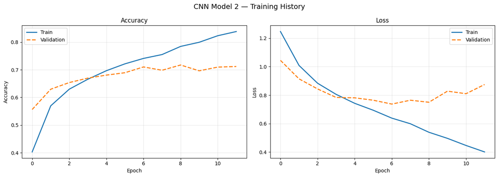

```python
early_stop_cnn2 = EarlyStopping(monitor='val_loss', patience=5,
                                restore_best_weights=True, verbose=1)

model_cnn2.compile(
    optimizer='adam',
    loss='categorical_crossentropy',
    metrics=['accuracy']
)

history_cnn2 = model_cnn2.fit(
    train_gen_gray,
    validation_data=val_gen_gray,
    epochs=20,
    callbacks=[early_stop_cnn2],
    verbose=1
)

plot_training(history_cnn2, 'CNN Model 2')
```

### **Evaluating CNN Model 2 on the Test Set**

We evaluate CNN Model 2 using the same protocol: held-out test set (128 images, balanced), classification report per class.

```python
evaluate_model(model_cnn2, test_gen_gray, 'CNN Model 2', model_results)

test_gen_gray.reset()
preds_cnn2 = np.argmax(model_cnn2.predict(test_gen_gray, verbose=0), axis=1)
print("\nClassification Report — CNN Model 2:")
print(classification_report(test_gen_gray.classes, preds_cnn2, target_names=CLASS_NAMES))
```

```
─────────────────────────────────────────────
CNN Model 2
  Test Loss:     0.6780
  Test Accuracy: 75.00%
─────────────────────────────────────────────

Classification Report — CNN Model 2:
              precision    recall  f1-score   support

       happy       0.73      0.84      0.78        32
     neutral       0.68      0.78      0.72        32
         sad       0.68      0.59      0.63        32
    surprise       0.96      0.78      0.86        32

    accuracy                           0.75       128
   macro avg       0.76      0.75      0.75       128
weighted avg       0.76      0.75      0.75       128
```

**Observations and Insights — CNN Model 2:**

CNN Model 2 achieves **75.00% test accuracy** — a **+5.47pp improvement** over CNN Model 1. EarlyStopping triggered at epoch 12, restoring weights from epoch 7.

| Class | Precision | Recall | F1-Score |
| --- | --- | --- | --- |
| happy | 0.73 | 0.84 | 0.78 |
| neutral | 0.68 | 0.78 | 0.72 |
| sad | 0.68 | 0.59 | 0.63 |
| surprise | 0.96 | 0.78 | 0.86 |
| **macro avg** | **0.76** | **0.75** | **0.75** |

Key improvements over CNN Model 1:

- **Happy: F1 0.65 → 0.78** — precision jumped to 0.73 and recall to 0.84. The third conv block learned more reliable smile-pattern features.
- **Neutral: F1 0.69 → 0.72** — modest gain; neutral/sad discrimination is still the hardest boundary.
- **Sad: F1 0.65 → 0.63** — a slight drop; as neutral improved, some boundary images shifted. Recall fell from 0.75 to 0.59, meaning the model is now under-predicting sad relative to CNN1.
- **Surprise: F1 0.81 → 0.86** — precision of 0.96 is exceptional; surprise is nearly perfectly identified.

**Think About It:**

## **Transfer Learning Architectures**

Transfer learning allows us to leverage convolutional feature extractors trained on ImageNet (1.2M images, 1,000 classes) as frozen feature backbones. We add a custom classification head and train only the head layers, preserving the learned low-level feature detectors (edges, textures) while adapting the high-level representation to our 4-class emotion task.

We will evaluate three architectures: **VGG16**, **ResNet50V2**, and **EfficientNetB0**. These require 3-channel (RGB) inputs, so a new set of data generators is created.

### **Creating our Data Loaders for Transfer Learning Architectures**

Transfer learning models require `color_mode = 'rgb'` and 3-channel inputs shaped `(48, 48, 3)`.

```python
# ── RGB data loaders (VGG16, ResNet50V2, EfficientNetB0) ─────────────────────
# No rescaling here — raw [0,255] pixel values are passed to each model.
# Each architecture applies its own preprocessing internally:
#   VGG16:          preprocess_input subtracts ImageNet channel means
#   ResNet50V2:     preprocess_input scales to [-1, 1]
#   EfficientNetB0: include_preprocessing=True (default) applies internal rescaling
train_datagen_rgb = ImageDataGenerator()
val_datagen_rgb   = ImageDataGenerator()
test_datagen_rgb  = ImageDataGenerator()

train_gen_rgb = train_datagen_rgb.flow_from_directory(
    train_dir,
    target_size=IMG_SIZE,
    color_mode='rgb',
    batch_size=BATCH_SIZE,
    class_mode='categorical',
    shuffle=True,
    seed=42
)

val_gen_rgb = val_datagen_rgb.flow_from_directory(
    validation_dir,
    target_size=IMG_SIZE,
    color_mode='rgb',
    batch_size=BATCH_SIZE,
    class_mode='categorical',
    shuffle=False
)

test_gen_rgb = test_datagen_rgb.flow_from_directory(
    test_dir,
    target_size=IMG_SIZE,
    color_mode='rgb',
    batch_size=BATCH_SIZE,
    class_mode='categorical',
    shuffle=False
)

print(f"RGB Train:      {train_gen_rgb.n} images | {len(train_gen_rgb)} batches")
print(f"RGB Validation: {val_gen_rgb.n} images  | {len(val_gen_rgb)} batches")
print(f"RGB Test:       {test_gen_rgb.n} images  | {len(test_gen_rgb)} batches")
```

```
Found 15109 images belonging to 4 classes.
Found 4977 images belonging to 4 classes.
Found 128 images belonging to 4 classes.
RGB Train:      15109 images | 473 batches
RGB Validation: 4977 images  | 156 batches
RGB Test:       128 images  | 4 batches
```

## **VGG16 Model**

### **Importing the VGG16 Architecture**

```python
# Load VGG16 with ImageNet weights, no top classifier
base_vgg16 = VGG16(weights='imagenet', include_top=False, input_shape=(48, 48, 3))
base_vgg16.trainable = False  # Freeze all convolutional layers

print(f"VGG16 trainable parameters: {sum(p.numpy().size for p in base_vgg16.trainable_variables)}")
print(f"VGG16 non-trainable parameters: {sum(p.numpy().size for p in base_vgg16.non_trainable_variables)}")
base_vgg16.summary()
```

```
Downloading data from https://storage.googleapis.com/tensorflow/keras-applications/vgg16/vgg16_weights_tf_dim_ordering_tf_kernels_notop.h5
58889256/58889256 ━━━━━━━━━━━━━━━━━━━━ 4s 0us/step
VGG16 trainable parameters: 0
VGG16 non-trainable parameters: 14714688
```

```
Model: "vgg16"
```

```
┏━━━━━━━━━━━━━━━━━━━━━━━━━━━━━━━━━┳━━━━━━━━━━━━━━━━━━━━━━━━┳━━━━━━━━━━━━━━━┓
┃ Layer (type)                    ┃ Output Shape           ┃       Param # ┃
┡━━━━━━━━━━━━━━━━━━━━━━━━━━━━━━━━━╇━━━━━━━━━━━━━━━━━━━━━━━━╇━━━━━━━━━━━━━━━┩
│ input_layer_3 (InputLayer)      │ (None, 48, 48, 3)      │             0 │
├─────────────────────────────────┼────────────────────────┼───────────────┤
│ block1_conv1 (Conv2D)           │ (None, 48, 48, 64)     │         1,792 │
├─────────────────────────────────┼────────────────────────┼───────────────┤
│ block1_conv2 (Conv2D)           │ (None, 48, 48, 64)     │        36,928 │
├─────────────────────────────────┼────────────────────────┼───────────────┤
│ block1_pool (MaxPooling2D)      │ (None, 24, 24, 64)     │             0 │
├─────────────────────────────────┼────────────────────────┼───────────────┤
│ block2_conv1 (Conv2D)           │ (None, 24, 24, 128)    │        73,856 │
├─────────────────────────────────┼────────────────────────┼───────────────┤
│ block2_conv2 (Conv2D)           │ (None, 24, 24, 128)    │       147,584 │
├─────────────────────────────────┼────────────────────────┼───────────────┤
│ block2_pool (MaxPooling2D)      │ (None, 12, 12, 128)    │             0 │
├─────────────────────────────────┼────────────────────────┼───────────────┤
│ block3_conv1 (Conv2D)           │ (None, 12, 12, 256)    │       295,168 │
├─────────────────────────────────┼────────────────────────┼───────────────┤
│ block3_conv2 (Conv2D)           │ (None, 12, 12, 256)    │       590,080 │
├─────────────────────────────────┼────────────────────────┼───────────────┤
│ block3_conv3 (Conv2D)           │ (None, 12, 12, 256)    │       590,080 │
├─────────────────────────────────┼────────────────────────┼───────────────┤
│ block3_pool (MaxPooling2D)      │ (None, 6, 6, 256)      │             0 │
├─────────────────────────────────┼────────────────────────┼───────────────┤
│ block4_conv1 (Conv2D)           │ (None, 6, 6, 512)      │     1,180,160 │
├─────────────────────────────────┼────────────────────────┼───────────────┤
│ block4_conv2 (Conv2D)           │ (None, 6, 6, 512)      │     2,359,808 │
├─────────────────────────────────┼────────────────────────┼───────────────┤
│ block4_conv3 (Conv2D)           │ (None, 6, 6, 512)      │     2,359,808 │
├─────────────────────────────────┼────────────────────────┼───────────────┤
│ block4_pool (MaxPooling2D)      │ (None, 3, 3, 512)      │             0 │
├─────────────────────────────────┼────────────────────────┼───────────────┤
│ block5_conv1 (Conv2D)           │ (None, 3, 3, 512)      │     2,359,808 │
├─────────────────────────────────┼────────────────────────┼───────────────┤
│ block5_conv2 (Conv2D)           │ (None, 3, 3, 512)      │     2,359,808 │
├─────────────────────────────────┼────────────────────────┼───────────────┤
│ block5_conv3 (Conv2D)           │ (None, 3, 3, 512)      │     2,359,808 │
├─────────────────────────────────┼────────────────────────┼───────────────┤
│ block5_pool (MaxPooling2D)      │ (None, 1, 1, 512)      │             0 │
└─────────────────────────────────┴────────────────────────┴───────────────┘
```

```
 Total params: 14,714,688 (56.13 MB)
```

```
 Trainable params: 0 (0.00 B)
```

```
 Non-trainable params: 14,714,688 (56.13 MB)
```

### **Model Building — VGG16**

Import VGG16 up to the final convolutional output and add fully connected layers on top.

```python
# VGG16: preprocess_input subtracts ImageNet channel means from [0,255] input
# Using Functional API so preprocessing sits inside the model graph
inputs_vgg = keras.Input(shape=(IMG_SIZE[0], IMG_SIZE[1], 3))
x = tf.keras.applications.vgg16.preprocess_input(inputs_vgg)
x = base_vgg16(x, training=False)
x = layers.GlobalAveragePooling2D()(x)
x = layers.Dense(256, activation='relu')(x)
x = layers.Dropout(0.5)(x)
outputs_vgg = layers.Dense(NUM_CLASSES, activation='softmax')(x)

model_vgg16 = keras.Model(inputs_vgg, outputs_vgg, name='VGG16_Transfer')
model_vgg16.summary()
```

```
Model: "VGG16_Transfer"
```

```
┏━━━━━━━━━━━━━━━━━━━━━┳━━━━━━━━━━━━━━━━━━━┳━━━━━━━━━━━━┳━━━━━━━━━━━━━━━━━━━┓
┃ Layer (type)        ┃ Output Shape      ┃    Param # ┃ Connected to      ┃
┡━━━━━━━━━━━━━━━━━━━━━╇━━━━━━━━━━━━━━━━━━━╇━━━━━━━━━━━━╇━━━━━━━━━━━━━━━━━━━┩
│ input_layer_4       │ (None, 48, 48, 3) │          0 │ -                 │
│ (InputLayer)        │                   │            │                   │
├─────────────────────┼───────────────────┼────────────┼───────────────────┤
│ get_item (GetItem)  │ (None, 48, 48)    │          0 │ input_layer_4[0]… │
├─────────────────────┼───────────────────┼────────────┼───────────────────┤
│ get_item_1          │ (None, 48, 48)    │          0 │ input_layer_4[0]… │
│ (GetItem)           │                   │            │                   │
├─────────────────────┼───────────────────┼────────────┼───────────────────┤
│ get_item_2          │ (None, 48, 48)    │          0 │ input_layer_4[0]… │
│ (GetItem)           │                   │            │                   │
├─────────────────────┼───────────────────┼────────────┼───────────────────┤
│ stack (Stack)       │ (None, 48, 48, 3) │          0 │ get_item[0][0],   │
│                     │                   │            │ get_item_1[0][0], │
│                     │                   │            │ get_item_2[0][0]  │
├─────────────────────┼───────────────────┼────────────┼───────────────────┤
│ add (Add)           │ (None, 48, 48, 3) │          0 │ stack[0][0]       │
├─────────────────────┼───────────────────┼────────────┼───────────────────┤
│ vgg16 (Functional)  │ (None, 1, 1, 512) │ 14,714,688 │ add[0][0]         │
├─────────────────────┼───────────────────┼────────────┼───────────────────┤
│ global_average_poo… │ (None, 512)       │          0 │ vgg16[0][0]       │
│ (GlobalAveragePool… │                   │            │                   │
├─────────────────────┼───────────────────┼────────────┼───────────────────┤
│ dense_7 (Dense)     │ (None, 256)       │    131,328 │ global_average_p… │
├─────────────────────┼───────────────────┼────────────┼───────────────────┤
│ dropout_4 (Dropout) │ (None, 256)       │          0 │ dense_7[0][0]     │
├─────────────────────┼───────────────────┼────────────┼───────────────────┤
│ dense_8 (Dense)     │ (None, 4)         │      1,028 │ dropout_4[0][0]   │
└─────────────────────┴───────────────────┴────────────┴───────────────────┘
```

```
 Total params: 14,847,044 (56.64 MB)
```

```
 Trainable params: 132,356 (517.02 KB)
```

```
 Non-trainable params: 14,714,688 (56.13 MB)
```

### **Compiling and Training the VGG16 Model**

```
473/473 ━━━━━━━━━━━━━━━━━━━━ 20s 32ms/step - accuracy: 0.3006 - loss: 13.0861 - val_accuracy: 0.4491 - val_loss: 3.3300
473/473 ━━━━━━━━━━━━━━━━━━━━ 10s 22ms/step - accuracy: 0.4004 - loss: 5.7834 - val_accuracy: 0.4778 - val_loss: 2.1907
473/473 ━━━━━━━━━━━━━━━━━━━━ 10s 22ms/step - accuracy: 0.4161 - loss: 3.3368 - val_accuracy: 0.4772 - val_loss: 1.6698
473/473 ━━━━━━━━━━━━━━━━━━━━ 10s 22ms/step - accuracy: 0.4313 - loss: 2.1258 - val_accuracy: 0.4684 - val_loss: 1.4405
473/473 ━━━━━━━━━━━━━━━━━━━━ 10s 21ms/step - accuracy: 0.4430 - loss: 1.6652 - val_accuracy: 0.4728 - val_loss: 1.3369
473/473 ━━━━━━━━━━━━━━━━━━━━ 10s 21ms/step - accuracy: 0.4484 - loss: 1.4657 - val_accuracy: 0.4772 - val_loss: 1.2937
473/473 ━━━━━━━━━━━━━━━━━━━━ 10s 22ms/step - accuracy: 0.4602 - loss: 1.3034 - val_accuracy: 0.4862 - val_loss: 1.2460
473/473 ━━━━━━━━━━━━━━━━━━━━ 10s 21ms/step - accuracy: 0.4753 - loss: 1.2578 - val_accuracy: 0.4941 - val_loss: 1.2213
473/473 ━━━━━━━━━━━━━━━━━━━━ 10s 21ms/step - accuracy: 0.4905 - loss: 1.1976 - val_accuracy: 0.4991 - val_loss: 1.2036
473/473 ━━━━━━━━━━━━━━━━━━━━ 10s 22ms/step - accuracy: 0.5002 - loss: 1.1524 - val_accuracy: 0.5065 - val_loss: 1.1885
Restoring model weights from the end of the best epoch: 10.
```

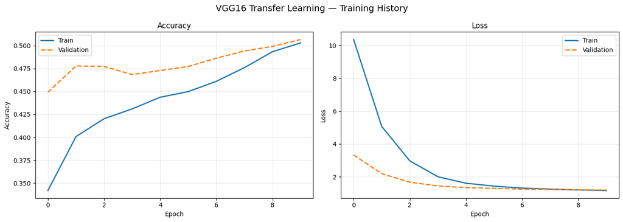

```python
early_stop_vgg = EarlyStopping(monitor='val_loss', patience=5,
                               restore_best_weights=True, verbose=1)

model_vgg16.compile(
    optimizer=keras.optimizers.Adam(learning_rate=1e-4),
    loss='categorical_crossentropy',
    metrics=['accuracy']
)

history_vgg16 = model_vgg16.fit(
    train_gen_rgb,
    validation_data=val_gen_rgb,
    epochs=10,
    callbacks=[early_stop_vgg],
    verbose=1
)

plot_training(history_vgg16, 'VGG16 Transfer Learning')
```

### **Evaluating the VGG16 Model**

```python
test_gen_rgb.reset()
evaluate_model(model_vgg16, test_gen_rgb, 'VGG16 Transfer', model_results)

preds_vgg = np.argmax(model_vgg16.predict(test_gen_rgb, verbose=0), axis=1)
print("\nClassification Report — VGG16:")
print(classification_report(test_gen_rgb.classes, preds_vgg, target_names=CLASS_NAMES))
```

```
─────────────────────────────────────────────
VGG16 Transfer
  Test Loss:     1.1832
  Test Accuracy: 51.56%
─────────────────────────────────────────────

Classification Report — VGG16:
              precision    recall  f1-score   support

       happy       0.55      0.66      0.60        32
     neutral       0.31      0.34      0.33        32
         sad       0.52      0.44      0.47        32
    surprise       0.71      0.62      0.67        32

    accuracy                           0.52       128
   macro avg       0.52      0.52      0.52       128
weighted avg       0.52      0.52      0.52       128
```

**Think About It:**

**Observations and Insights — VGG16:**

VGG16 achieves **51.56% test accuracy** — identical to the ANN baseline and **23.44pp below CNN Model 2**. The model ran all 10 epochs without EarlyStopping.

| Class | Precision | Recall | F1-Score |
| --- | --- | --- | --- |
| happy | 0.55 | 0.66 | 0.60 |
| neutral | 0.31 | 0.34 | 0.33 |
| sad | 0.52 | 0.44 | 0.47 |
| surprise | 0.71 | 0.62 | 0.67 |
| **macro avg** | **0.52** | **0.52** | **0.52** |

**Domain gap signature**: VGG16's ImageNet backbone learned object-level semantics from high-resolution, colourful natural images. Applied to 48×48 grayscale facial micro-expressions, the frozen features carry limited relevant signal. The model ran all 10 epochs without triggering EarlyStopping — it never meaningfully overfit, but it also never found a useful minimum. This is the characteristic signature of domain gap: wrong features, not overfitting.

**Neutral is the most damaged class** (F1 0.33, precision 0.31) — the "absence of expression" signal has no analogue in ImageNet object features. The result is striking: VGG16 with 14.7M backbone parameters achieves the same accuracy as a flat dense network. Pre-training on the wrong domain is as limiting as having no convolutional structure at all.

**Note:** Fine-tuning — progressively unfreezing VGG16 backbone layers with a reduced learning rate — is identified as a future improvement in the conclusion. For this experiment, the frozen backbone establishes the domain gap baseline.

## **ResNet V2 Model**

```python
# Load ResNet50V2 with ImageNet weights
base_resnet = ResNet50V2(weights='imagenet', include_top=False, input_shape=(48, 48, 3))
base_resnet.trainable = False  # Freeze backbone

print(f"ResNet50V2 total parameters: {base_resnet.count_params():,}")
```

```
Downloading data from https://storage.googleapis.com/tensorflow/keras-applications/resnet/resnet50v2_weights_tf_dim_ordering_tf_kernels_notop.h5
94668760/94668760 ━━━━━━━━━━━━━━━━━━━━ 6s 0us/step
ResNet50V2 total parameters: 23,564,800
```

### **Model Building — ResNet50V2**

Import ResNet50V2 and add fully connected layers on top.

```python
# ResNet50V2: preprocess_input scales [0,255] to [-1, 1]  (x/127.5 - 1)
# Using Functional API so preprocessing sits inside the model graph
inputs_resnet = keras.Input(shape=(IMG_SIZE[0], IMG_SIZE[1], 3))
x = tf.keras.applications.resnet_v2.preprocess_input(inputs_resnet)
x = base_resnet(x, training=False)
x = layers.GlobalAveragePooling2D()(x)
x = layers.Dense(256, activation='relu')(x)
x = layers.Dropout(0.5)(x)
outputs_resnet = layers.Dense(NUM_CLASSES, activation='softmax')(x)

model_resnet = keras.Model(inputs_resnet, outputs_resnet, name='ResNet50V2_Transfer')
model_resnet.summary()
```

```
Model: "ResNet50V2_Transfer"
```

```
┏━━━━━━━━━━━━━━━━━━━━━━━━━━━━━━━━━┳━━━━━━━━━━━━━━━━━━━━━━━━┳━━━━━━━━━━━━━━━┓
┃ Layer (type)                    ┃ Output Shape           ┃       Param # ┃
┡━━━━━━━━━━━━━━━━━━━━━━━━━━━━━━━━━╇━━━━━━━━━━━━━━━━━━━━━━━━╇━━━━━━━━━━━━━━━┩
│ input_layer_6 (InputLayer)      │ (None, 48, 48, 3)      │             0 │
├─────────────────────────────────┼────────────────────────┼───────────────┤
│ true_divide (TrueDivide)        │ (None, 48, 48, 3)      │             0 │
├─────────────────────────────────┼────────────────────────┼───────────────┤
│ subtract (Subtract)             │ (None, 48, 48, 3)      │             0 │
├─────────────────────────────────┼────────────────────────┼───────────────┤
│ resnet50v2 (Functional)         │ (None, 2, 2, 2048)     │    23,564,800 │
├─────────────────────────────────┼────────────────────────┼───────────────┤
│ global_average_pooling2d_1      │ (None, 2048)           │             0 │
│ (GlobalAveragePooling2D)        │                        │               │
├─────────────────────────────────┼────────────────────────┼───────────────┤
│ dense_9 (Dense)                 │ (None, 256)            │       524,544 │
├─────────────────────────────────┼────────────────────────┼───────────────┤
│ dropout_5 (Dropout)             │ (None, 256)            │             0 │
├─────────────────────────────────┼────────────────────────┼───────────────┤
│ dense_10 (Dense)                │ (None, 4)              │         1,028 │
└─────────────────────────────────┴────────────────────────┴───────────────┘
```

```
 Total params: 24,090,372 (91.90 MB)
```

```
 Trainable params: 525,572 (2.00 MB)
```

```
 Non-trainable params: 23,564,800 (89.89 MB)
```

### **Compiling and Training the ResNet50V2 Model**

```
473/473 ━━━━━━━━━━━━━━━━━━━━ 33s 45ms/step - accuracy: 0.3354 - loss: 2.4067 - val_accuracy: 0.4804 - val_loss: 1.2058
473/473 ━━━━━━━━━━━━━━━━━━━━ 10s 22ms/step - accuracy: 0.4463 - loss: 1.2568 - val_accuracy: 0.5065 - val_loss: 1.1608
473/473 ━━━━━━━━━━━━━━━━━━━━ 12s 26ms/step - accuracy: 0.4910 - loss: 1.1603 - val_accuracy: 0.5182 - val_loss: 1.1377
473/473 ━━━━━━━━━━━━━━━━━━━━ 9s 20ms/step - accuracy: 0.5267 - loss: 1.0998 - val_accuracy: 0.5304 - val_loss: 1.1104
473/473 ━━━━━━━━━━━━━━━━━━━━ 10s 20ms/step - accuracy: 0.5556 - loss: 1.0306 - val_accuracy: 0.5373 - val_loss: 1.1040
473/473 ━━━━━━━━━━━━━━━━━━━━ 10s 21ms/step - accuracy: 0.5711 - loss: 1.0171 - val_accuracy: 0.5463 - val_loss: 1.0777
473/473 ━━━━━━━━━━━━━━━━━━━━ 12s 25ms/step - accuracy: 0.5895 - loss: 0.9825 - val_accuracy: 0.5349 - val_loss: 1.0942
473/473 ━━━━━━━━━━━━━━━━━━━━ 9s 19ms/step - accuracy: 0.6002 - loss: 0.9529 - val_accuracy: 0.5521 - val_loss: 1.0744
473/473 ━━━━━━━━━━━━━━━━━━━━ 10s 22ms/step - accuracy: 0.6241 - loss: 0.9107 - val_accuracy: 0.5574 - val_loss: 1.0764
473/473 ━━━━━━━━━━━━━━━━━━━━ 10s 21ms/step - accuracy: 0.6315 - loss: 0.8886 - val_accuracy: 0.5576 - val_loss: 1.0764
Restoring model weights from the end of the best epoch: 8.
```

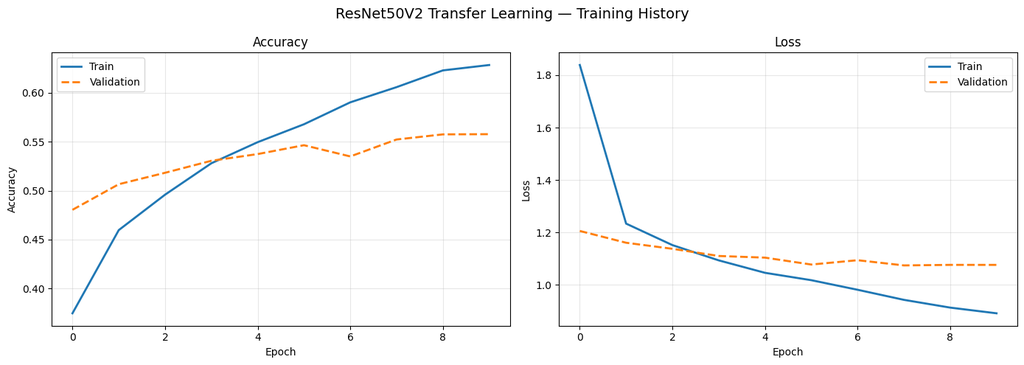

```python
early_stop_resnet = EarlyStopping(monitor='val_loss', patience=5,
                                   restore_best_weights=True, verbose=1)

model_resnet.compile(
    optimizer=keras.optimizers.Adam(learning_rate=1e-4),
    loss='categorical_crossentropy',
    metrics=['accuracy']
)

history_resnet = model_resnet.fit(
    train_gen_rgb,
    validation_data=val_gen_rgb,
    epochs=10,
    callbacks=[early_stop_resnet],
    verbose=1
)

plot_training(history_resnet, 'ResNet50V2 Transfer Learning')
```

### **Evaluating the ResNet50V2 Model**

```python
test_gen_rgb.reset()
evaluate_model(model_resnet, test_gen_rgb, 'ResNet50V2 Transfer', model_results)

preds_resnet = np.argmax(model_resnet.predict(test_gen_rgb, verbose=0), axis=1)
print("\nClassification Report — ResNet50V2:")
print(classification_report(test_gen_rgb.classes, preds_resnet, target_names=CLASS_NAMES))
```

```
─────────────────────────────────────────────
ResNet50V2 Transfer
  Test Loss:     1.0878
  Test Accuracy: 55.47%
─────────────────────────────────────────────

Classification Report — ResNet50V2:
              precision    recall  f1-score   support

       happy       0.52      0.69      0.59        32
     neutral       0.40      0.38      0.39        32
         sad       0.59      0.50      0.54        32
    surprise       0.72      0.66      0.69        32

    accuracy                           0.55       128
   macro avg       0.56      0.55      0.55       128
weighted avg       0.56      0.55      0.55       128
```

**Observations and Insights — ResNet50V2:**

ResNet50V2 achieves **55.47% test accuracy**. EarlyStopping restored weights from epoch 8, running all 10 epochs.

| Class | Precision | Recall | F1-Score |
| --- | --- | --- | --- |
| happy | 0.52 | 0.69 | 0.59 |
| neutral | 0.40 | 0.38 | 0.39 |
| sad | 0.59 | 0.50 | 0.54 |
| surprise | 0.72 | 0.66 | 0.69 |
| **macro avg** | **0.56** | **0.55** | **0.55** |

ResNet50V2 edges ahead of VGG16 by 3.91pp — its residual connections provide marginally better gradient flow for the trainable head layers. But the domain gap remains the binding constraint. **Neutral (F1 0.39)** is again the most severely weakened class — the absence-of-expression signal that defines neutral faces has no analogue in ResNet's ImageNet-trained feature space.

Across three transfer learning models, the pattern is consistent: all three never trigger EarlyStopping (no overfitting), plateau in the 51–60% range, and struggle most with the neutral class. This is not an architecture-specific failure — it is a domain gap failure shared across all frozen backbones trained on natural images.

## **EfficientNet Model**

```python
# Load EfficientNetB0 with ImageNet weights
base_effnet = EfficientNetB0(weights='imagenet', include_top=False, input_shape=(48, 48, 3))
base_effnet.trainable = False  # Freeze backbone

print(f"EfficientNetB0 total parameters: {base_effnet.count_params():,}")
```

```
Downloading data from https://storage.googleapis.com/keras-applications/efficientnetb0_notop.h5
16705208/16705208 ━━━━━━━━━━━━━━━━━━━━ 2s 0us/step
EfficientNetB0 total parameters: 4,049,571
```

### **Model Building — EfficientNetB0**

Import EfficientNetB0 and add fully connected layers on top.

```python
# EfficientNetB0: include_preprocessing=True (Keras default)
# The model contains a built-in Rescaling layer that handles [0,255] → [0,1] internally.
# No external preprocessing needed — raw pixel values from the generator are correct.
model_effnet = keras.Sequential([
    base_effnet,
    layers.GlobalAveragePooling2D(),
    layers.Dense(256, activation='relu'),
    layers.Dropout(0.5),
    layers.Dense(NUM_CLASSES, activation='softmax')
], name='EfficientNetB0_Transfer')

model_effnet.summary()
```

```
Model: "EfficientNetB0_Transfer"
```

```
┏━━━━━━━━━━━━━━━━━━━━━━━━━━━━━━━━━┳━━━━━━━━━━━━━━━━━━━━━━━━┳━━━━━━━━━━━━━━━┓
┃ Layer (type)                    ┃ Output Shape           ┃       Param # ┃
┡━━━━━━━━━━━━━━━━━━━━━━━━━━━━━━━━━╇━━━━━━━━━━━━━━━━━━━━━━━━╇━━━━━━━━━━━━━━━┩
│ efficientnetb0 (Functional)     │ (None, 2, 2, 1280)     │     4,049,571 │
├─────────────────────────────────┼────────────────────────┼───────────────┤
│ global_average_pooling2d_2      │ (None, 1280)           │             0 │
│ (GlobalAveragePooling2D)        │                        │               │
├─────────────────────────────────┼────────────────────────┼───────────────┤
│ dense_11 (Dense)                │ (None, 256)            │       327,936 │
├─────────────────────────────────┼────────────────────────┼───────────────┤
│ dropout_6 (Dropout)             │ (None, 256)            │             0 │
├─────────────────────────────────┼────────────────────────┼───────────────┤
│ dense_12 (Dense)                │ (None, 4)              │         1,028 │
└─────────────────────────────────┴────────────────────────┴───────────────┘
```

```
 Total params: 4,378,535 (16.70 MB)
```

```
 Trainable params: 328,964 (1.25 MB)
```

```
 Non-trainable params: 4,049,571 (15.45 MB)
```

### **Compiling and Training the EfficientNetB0 Model**

```
473/473 ━━━━━━━━━━━━━━━━━━━━ 71s 93ms/step - accuracy: 0.4070 - loss: 1.2694 - val_accuracy: 0.5481 - val_loss: 1.0626
473/473 ━━━━━━━━━━━━━━━━━━━━ 9s 19ms/step - accuracy: 0.5154 - loss: 1.1085 - val_accuracy: 0.5550 - val_loss: 1.0480
473/473 ━━━━━━━━━━━━━━━━━━━━ 11s 22ms/step - accuracy: 0.5356 - loss: 1.0695 - val_accuracy: 0.5582 - val_loss: 1.0431
473/473 ━━━━━━━━━━━━━━━━━━━━ 11s 23ms/step - accuracy: 0.5506 - loss: 1.0452 - val_accuracy: 0.5758 - val_loss: 1.0146
473/473 ━━━━━━━━━━━━━━━━━━━━ 9s 19ms/step - accuracy: 0.5525 - loss: 1.0291 - val_accuracy: 0.5887 - val_loss: 0.9853
473/473 ━━━━━━━━━━━━━━━━━━━━ 11s 23ms/step - accuracy: 0.5693 - loss: 1.0169 - val_accuracy: 0.5927 - val_loss: 0.9840
473/473 ━━━━━━━━━━━━━━━━━━━━ 11s 23ms/step - accuracy: 0.5734 - loss: 1.0059 - val_accuracy: 0.5949 - val_loss: 0.9754
473/473 ━━━━━━━━━━━━━━━━━━━━ 11s 23ms/step - accuracy: 0.5817 - loss: 0.9877 - val_accuracy: 0.5957 - val_loss: 0.9589
473/473 ━━━━━━━━━━━━━━━━━━━━ 9s 18ms/step - accuracy: 0.5831 - loss: 0.9761 - val_accuracy: 0.5955 - val_loss: 0.9725
473/473 ━━━━━━━━━━━━━━━━━━━━ 10s 22ms/step - accuracy: 0.5833 - loss: 0.9743 - val_accuracy: 0.6054 - val_loss: 0.9554
Restoring model weights from the end of the best epoch: 10.
```

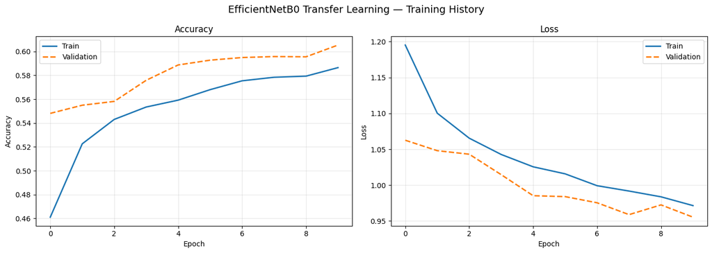

```python
early_stop_eff = EarlyStopping(monitor='val_loss', patience=5,
                               restore_best_weights=True, verbose=1)

model_effnet.compile(
    optimizer=keras.optimizers.Adam(learning_rate=1e-4),
    loss='categorical_crossentropy',
    metrics=['accuracy']
)

history_effnet = model_effnet.fit(
    train_gen_rgb,
    validation_data=val_gen_rgb,
    epochs=10,
    callbacks=[early_stop_eff],
    verbose=1
)

plot_training(history_effnet, 'EfficientNetB0 Transfer Learning')
```

### **Evaluating the EfficientNetB0 Model**

```python
test_gen_rgb.reset()
evaluate_model(model_effnet, test_gen_rgb, 'EfficientNetB0 Transfer', model_results)

preds_effnet = np.argmax(model_effnet.predict(test_gen_rgb, verbose=0), axis=1)
print("\nClassification Report — EfficientNetB0:")
print(classification_report(test_gen_rgb.classes, preds_effnet, target_names=CLASS_NAMES))
```

```
─────────────────────────────────────────────
EfficientNetB0 Transfer
  Test Loss:     0.9352
  Test Accuracy: 60.16%
─────────────────────────────────────────────

Classification Report — EfficientNetB0:
              precision    recall  f1-score   support

       happy       0.65      0.69      0.67        32
     neutral       0.43      0.28      0.34        32
         sad       0.52      0.72      0.61        32
    surprise       0.79      0.72      0.75        32

    accuracy                           0.60       128
   macro avg       0.60      0.60      0.59       128
weighted avg       0.60      0.60      0.59       128
```

**Observations and Insights — EfficientNetB0:**

EfficientNetB0 achieves **60.16% test accuracy** — the strongest transfer learning result, though still **14.84pp below CNN Model 2** (75.00%) and **21.87pp below the Complex CNN** (82.03%). The model ran all 10 epochs.

| Class | Precision | Recall | F1-Score |
| --- | --- | --- | --- |
| happy | 0.65 | 0.69 | 0.67 |
| neutral | 0.43 | 0.28 | 0.34 |
| sad | 0.52 | 0.72 | 0.61 |
| surprise | 0.79 | 0.72 | 0.75 |
| **macro avg** | **0.60** | **0.60** | **0.59** |

**Preprocessing note**: EfficientNetB0's `include_preprocessing=True` (Keras default) applies internal rescaling from [0,255] to [0,1] inside the model graph. RGB generators pass raw pixel values; the model handles normalisation internally. An earlier version used `rescale=1./255` in the data generator, which combined with EfficientNet's internal rescaling caused double-scaling to near-zero inputs and **complete mode collapse** (25% accuracy). Removing the external rescale and using model-specific preprocessing per architecture restored genuine learning — a practical engineering lesson about respecting each architecture's preprocessing contract.

**Neutral (F1 0.34)** is the most damaged class — a pattern consistent across all three TL architectures. EfficientNet's compound scaling improves happy and surprise relative to VGG16 and ResNet, but neutral remains below F1 0.40 across all three models. The domain gap is not architecture-specific; it is task-specific.

**Think About It:**

Now that we have tried multiple pre-trained models, let's build a complex CNN architecture and see if we can get better performance.

## **Building a Complex Neural Network Architecture**

In this section, we will build a more complex Convolutional Neural Network model that approaches the parameter count of the transfer learning models while operating natively on grayscale images.

**Design principles:**

- **5 convolutional blocks** with progressively increasing filter sizes (64 → 128 → 256 → 256 → 512)
- **Batch Normalization** after each conv layer to stabilize training and act as a regularizer
- **Dropout** after each pooling block to prevent overfitting
- **Data Augmentation** in the training generator (rotation, shift, zoom, horizontal flip) to improve generalization
- **ReduceLROnPlateau** to adaptively decrease the learning rate when validation loss stagnates
- **1-channel (grayscale) inputs** — appropriate for this domain, avoiding artificial RGB conversion

## **Creating our Data Loaders for the Complex CNN**

We go ahead with `color_mode = 'grayscale'`. We also add **data augmentation** to the training generator to improve generalization, especially for the under-represented `surprise` class.

```python
# ── Augmented grayscale data loaders for Complex CNN ──
train_datagen_aug = ImageDataGenerator(
    rescale=1./255,
    rotation_range=15,
    width_shift_range=0.1,
    height_shift_range=0.1,
    zoom_range=0.1,
    horizontal_flip=True,        # Facial expressions are broadly symmetric
    fill_mode='nearest'
)

val_datagen_aug  = ImageDataGenerator(rescale=1./255)
test_datagen_aug = ImageDataGenerator(rescale=1./255)

train_gen_aug = train_datagen_aug.flow_from_directory(
    train_dir,
    target_size=IMG_SIZE,
    color_mode='grayscale',
    batch_size=BATCH_SIZE,
    class_mode='categorical',
    shuffle=True,
    seed=42
)

val_gen_aug = val_datagen_aug.flow_from_directory(
    validation_dir,
    target_size=IMG_SIZE,
    color_mode='grayscale',
    batch_size=BATCH_SIZE,
    class_mode='categorical',
    shuffle=False
)

test_gen_aug = test_datagen_aug.flow_from_directory(
    test_dir,
    target_size=IMG_SIZE,
    color_mode='grayscale',
    batch_size=BATCH_SIZE,
    class_mode='categorical',
    shuffle=False
)

print(f"Augmented Train:  {train_gen_aug.n} images | {len(train_gen_aug)} batches")
print(f"Augmented Val:    {val_gen_aug.n} images  | {len(val_gen_aug)} batches")
print(f"Augmented Test:   {test_gen_aug.n} images  | {len(test_gen_aug)} batches")
```

```
Found 15109 images belonging to 4 classes.
Found 4977 images belonging to 4 classes.
Found 128 images belonging to 4 classes.
Augmented Train:  15109 images | 473 batches
Augmented Val:    4977 images  | 156 batches
Augmented Test:   128 images  | 4 batches
```

### **Model Building — Complex CNN (5 Convolutional Blocks)**

Try building a model with 5 convolutional blocks and see if performance increases.

```python
# ── Complex CNN: 5 Convolutional Blocks with BatchNorm ──
model_complex = keras.Sequential([

    # ── Block 1: 64 filters ──
    layers.Conv2D(64, (3, 3), padding='same', input_shape=(48, 48, 1)),
    layers.BatchNormalization(),
    layers.Activation('relu'),
    layers.Conv2D(64, (3, 3), padding='same'),
    layers.BatchNormalization(),
    layers.Activation('relu'),
    layers.MaxPooling2D(2, 2),
    layers.Dropout(0.25),

    # ── Block 2: 128 filters ──
    layers.Conv2D(128, (3, 3), padding='same'),
    layers.BatchNormalization(),
    layers.Activation('relu'),
    layers.Conv2D(128, (3, 3), padding='same'),
    layers.BatchNormalization(),
    layers.Activation('relu'),
    layers.MaxPooling2D(2, 2),
    layers.Dropout(0.25),

    # ── Block 3: 256 filters ──
    layers.Conv2D(256, (3, 3), padding='same'),
    layers.BatchNormalization(),
    layers.Activation('relu'),
    layers.Conv2D(256, (3, 3), padding='same'),
    layers.BatchNormalization(),
    layers.Activation('relu'),
    layers.MaxPooling2D(2, 2),
    layers.Dropout(0.25),

    # ── Block 4: 256 filters ──
    layers.Conv2D(256, (3, 3), padding='same'),
    layers.BatchNormalization(),
    layers.Activation('relu'),
    layers.Conv2D(256, (3, 3), padding='same'),
    layers.BatchNormalization(),
    layers.Activation('relu'),
    layers.MaxPooling2D(2, 2),
    layers.Dropout(0.25),

    # ── Block 5: 512 filters → GlobalAvgPool ──
    layers.Conv2D(512, (3, 3), padding='same'),
    layers.BatchNormalization(),
    layers.Activation('relu'),
    layers.GlobalAveragePooling2D(),   # No MaxPool needed; GAP replaces Flatten

    # ── Dense classifier head ──
    layers.Dense(512, activation='relu'),
    layers.Dropout(0.5),
    layers.Dense(256, activation='relu'),
    layers.Dropout(0.3),
    layers.Dense(NUM_CLASSES, activation='softmax')

], name='Complex_CNN_5Blocks')

model_complex.summary()
```

```
Model: "Complex_CNN_5Blocks"
```

```
┏━━━━━━━━━━━━━━━━━━━━━━━━━━━━━━━━━┳━━━━━━━━━━━━━━━━━━━━━━━━┳━━━━━━━━━━━━━━━┓
┃ Layer (type)                    ┃ Output Shape           ┃       Param # ┃
┡━━━━━━━━━━━━━━━━━━━━━━━━━━━━━━━━━╇━━━━━━━━━━━━━━━━━━━━━━━━╇━━━━━━━━━━━━━━━┩
│ conv2d_5 (Conv2D)               │ (None, 48, 48, 64)     │           640 │
├─────────────────────────────────┼────────────────────────┼───────────────┤
│ batch_normalization_1           │ (None, 48, 48, 64)     │           256 │
│ (BatchNormalization)            │                        │               │
├─────────────────────────────────┼────────────────────────┼───────────────┤
│ activation (Activation)         │ (None, 48, 48, 64)     │             0 │
├─────────────────────────────────┼────────────────────────┼───────────────┤
│ conv2d_6 (Conv2D)               │ (None, 48, 48, 64)     │        36,928 │
├─────────────────────────────────┼────────────────────────┼───────────────┤
│ batch_normalization_2           │ (None, 48, 48, 64)     │           256 │
│ (BatchNormalization)            │                        │               │
├─────────────────────────────────┼────────────────────────┼───────────────┤
│ activation_1 (Activation)       │ (None, 48, 48, 64)     │             0 │
├─────────────────────────────────┼────────────────────────┼───────────────┤
│ max_pooling2d_8 (MaxPooling2D)  │ (None, 24, 24, 64)     │             0 │
├─────────────────────────────────┼────────────────────────┼───────────────┤
│ dropout_7 (Dropout)             │ (None, 24, 24, 64)     │             0 │
├─────────────────────────────────┼────────────────────────┼───────────────┤
│ conv2d_7 (Conv2D)               │ (None, 24, 24, 128)    │        73,856 │
├─────────────────────────────────┼────────────────────────┼───────────────┤
│ batch_normalization_3           │ (None, 24, 24, 128)    │           512 │
│ (BatchNormalization)            │                        │               │
├─────────────────────────────────┼────────────────────────┼───────────────┤
│ activation_2 (Activation)       │ (None, 24, 24, 128)    │             0 │
├─────────────────────────────────┼────────────────────────┼───────────────┤
│ conv2d_8 (Conv2D)               │ (None, 24, 24, 128)    │       147,584 │
├─────────────────────────────────┼────────────────────────┼───────────────┤
│ batch_normalization_4           │ (None, 24, 24, 128)    │           512 │
│ (BatchNormalization)            │                        │               │
├─────────────────────────────────┼────────────────────────┼───────────────┤
│ activation_3 (Activation)       │ (None, 24, 24, 128)    │             0 │
├─────────────────────────────────┼────────────────────────┼───────────────┤
│ max_pooling2d_9 (MaxPooling2D)  │ (None, 12, 12, 128)    │             0 │
├─────────────────────────────────┼────────────────────────┼───────────────┤
│ dropout_8 (Dropout)             │ (None, 12, 12, 128)    │             0 │
├─────────────────────────────────┼────────────────────────┼───────────────┤
│ conv2d_9 (Conv2D)               │ (None, 12, 12, 256)    │       295,168 │
```

[output cut: 40 more lines]

```
│ activation_8 (Activation)       │ (None, 3, 3, 512)      │             0 │
├─────────────────────────────────┼────────────────────────┼───────────────┤
│ global_average_pooling2d_3      │ (None, 512)            │             0 │
│ (GlobalAveragePooling2D)        │                        │               │
├─────────────────────────────────┼────────────────────────┼───────────────┤
│ dense_13 (Dense)                │ (None, 512)            │       262,656 │
├─────────────────────────────────┼────────────────────────┼───────────────┤
│ dropout_11 (Dropout)            │ (None, 512)            │             0 │
├─────────────────────────────────┼────────────────────────┼───────────────┤
│ dense_14 (Dense)                │ (None, 256)            │       131,328 │
├─────────────────────────────────┼────────────────────────┼───────────────┤
│ dropout_12 (Dropout)            │ (None, 256)            │             0 │
├─────────────────────────────────┼────────────────────────┼───────────────┤
│ dense_15 (Dense)                │ (None, 4)              │         1,028 │
└─────────────────────────────────┴────────────────────────┴───────────────┘
```

```
 Total params: 3,907,268 (14.91 MB)
```

```
 Trainable params: 3,903,428 (14.89 MB)
```

```
 Non-trainable params: 3,840 (15.00 KB)
```

### **Compiling and Training the Complex CNN**

```
473/473 ━━━━━━━━━━━━━━━━━━━━ 51s 67ms/step - accuracy: 0.3109 - loss: 1.3861 - val_accuracy: 0.3952 - val_loss: 1.2857 - learning_rate: 0.0010
473/473 ━━━━━━━━━━━━━━━━━━━━ 18s 39ms/step - accuracy: 0.4707 - loss: 1.1222 - val_accuracy: 0.4706 - val_loss: 1.1394 - learning_rate: 0.0010
473/473 ━━━━━━━━━━━━━━━━━━━━ 18s 38ms/step - accuracy: 0.5838 - loss: 0.9622 - val_accuracy: 0.6387 - val_loss: 0.8738 - learning_rate: 0.0010
473/473 ━━━━━━━━━━━━━━━━━━━━ 18s 37ms/step - accuracy: 0.6211 - loss: 0.8817 - val_accuracy: 0.6219 - val_loss: 0.8691 - learning_rate: 0.0010
473/473 ━━━━━━━━━━━━━━━━━━━━ 18s 37ms/step - accuracy: 0.6652 - loss: 0.8209 - val_accuracy: 0.6271 - val_loss: 0.9137 - learning_rate: 0.0010
473/473 ━━━━━━━━━━━━━━━━━━━━ 18s 39ms/step - accuracy: 0.6774 - loss: 0.7876 - val_accuracy: 0.6219 - val_loss: 0.9329 - learning_rate: 0.0010
473/473 ━━━━━━━━━━━━━━━━━━━━ 18s 37ms/step - accuracy: 0.6815 - loss: 0.7733 - val_accuracy: 0.6608 - val_loss: 0.8186 - learning_rate: 0.0010
473/473 ━━━━━━━━━━━━━━━━━━━━ 17s 37ms/step - accuracy: 0.6932 - loss: 0.7456 - val_accuracy: 0.7111 - val_loss: 0.8060 - learning_rate: 0.0010
473/473 ━━━━━━━━━━━━━━━━━━━━ 17s 37ms/step - accuracy: 0.6915 - loss: 0.7626 - val_accuracy: 0.7243 - val_loss: 0.6726 - learning_rate: 0.0010
473/473 ━━━━━━━━━━━━━━━━━━━━ 18s 38ms/step - accuracy: 0.7257 - loss: 0.7134 - val_accuracy: 0.7476 - val_loss: 0.6997 - learning_rate: 0.0010
473/473 ━━━━━━━━━━━━━━━━━━━━ 18s 38ms/step - accuracy: 0.7165 - loss: 0.7131 - val_accuracy: 0.7265 - val_loss: 0.6959 - learning_rate: 0.0010
473/473 ━━━━━━━━━━━━━━━━━━━━ 18s 37ms/step - accuracy: 0.7353 - loss: 0.6907 - val_accuracy: 0.7209 - val_loss: 0.7778 - learning_rate: 0.0010
472/473 ━━━━━━━━━━━━━━━━━━━━ 0s 33ms/step - accuracy: 0.7270 - loss: 0.6875
Epoch 13: ReduceLROnPlateau reducing learning rate to 0.00020000000949949026.
473/473 ━━━━━━━━━━━━━━━━━━━━ 18s 37ms/step - accuracy: 0.7270 - loss: 0.6875 - val_accuracy: 0.6747 - val_loss: 0.7848 - learning_rate: 0.0010
473/473 ━━━━━━━━━━━━━━━━━━━━ 18s 39ms/step - accuracy: 0.7319 - loss: 0.6528 - val_accuracy: 0.7527 - val_loss: 0.6503 - learning_rate: 2.0000e-04
473/473 ━━━━━━━━━━━━━━━━━━━━ 18s 38ms/step - accuracy: 0.7600 - loss: 0.6105 - val_accuracy: 0.7639 - val_loss: 0.6485 - learning_rate: 2.0000e-04
473/473 ━━━━━━━━━━━━━━━━━━━━ 18s 37ms/step - accuracy: 0.7599 - loss: 0.6029 - val_accuracy: 0.7641 - val_loss: 0.6444 - learning_rate: 2.0000e-04
473/473 ━━━━━━━━━━━━━━━━━━━━ 17s 37ms/step - accuracy: 0.7674 - loss: 0.6046 - val_accuracy: 0.7629 - val_loss: 0.6539 - learning_rate: 2.0000e-04
473/473 ━━━━━━━━━━━━━━━━━━━━ 18s 37ms/step - accuracy: 0.7559 - loss: 0.6084 - val_accuracy: 0.7637 - val_loss: 0.6469 - learning_rate: 2.0000e-04
473/473 ━━━━━━━━━━━━━━━━━━━━ 17s 37ms/step - accuracy: 0.7692 - loss: 0.5939 - val_accuracy: 0.7659 - val_loss: 0.6240 - learning_rate: 2.0000e-04
473/473 ━━━━━━━━━━━━━━━━━━━━ 18s 38ms/step - accuracy: 0.7646 - loss: 0.5996 - val_accuracy: 0.7655 - val_loss: 0.6255 - learning_rate: 2.0000e-04
473/473 ━━━━━━━━━━━━━━━━━━━━ 17s 36ms/step - accuracy: 0.7702 - loss: 0.5829 - val_accuracy: 0.7728 - val_loss: 0.6113 - learning_rate: 2.0000e-04
473/473 ━━━━━━━━━━━━━━━━━━━━ 17s 36ms/step - accuracy: 0.7684 - loss: 0.5724 - val_accuracy: 0.7685 - val_loss: 0.6179 - learning_rate: 2.0000e-04
473/473 ━━━━━━━━━━━━━━━━━━━━ 18s 38ms/step - accuracy: 0.7660 - loss: 0.5829 - val_accuracy: 0.7699 - val_loss: 0.6037 - learning_rate: 2.0000e-04
473/473 ━━━━━━━━━━━━━━━━━━━━ 17s 36ms/step - accuracy: 0.7806 - loss: 0.5664 - val_accuracy: 0.7740 - val_loss: 0.6125 - learning_rate: 2.0000e-04
473/473 ━━━━━━━━━━━━━━━━━━━━ 17s 36ms/step - accuracy: 0.7808 - loss: 0.5586 - val_accuracy: 0.7748 - val_loss: 0.6076 - learning_rate: 2.0000e-04
473/473 ━━━━━━━━━━━━━━━━━━━━ 17s 36ms/step - accuracy: 0.7794 - loss: 0.5677 - val_accuracy: 0.7569 - val_loss: 0.6243 - learning_rate: 2.0000e-04
473/473 ━━━━━━━━━━━━━━━━━━━━ 0s 32ms/step - accuracy: 0.7841 - loss: 0.5502
Epoch 27: ReduceLROnPlateau reducing learning rate to 4.0000001899898055e-05.
473/473 ━━━━━━━━━━━━━━━━━━━━ 18s 38ms/step - accuracy: 0.7841 - loss: 0.5503 - val_accuracy: 0.7756 - val_loss: 0.6325 - learning_rate: 2.0000e-04
473/473 ━━━━━━━━━━━━━━━━━━━━ 18s 38ms/step - accuracy: 0.7875 - loss: 0.5334 - val_accuracy: 0.7794 - val_loss: 0.5950 - learning_rate: 4.0000e-05
473/473 ━━━━━━━━━━━━━━━━━━━━ 17s 36ms/step - accuracy: 0.7888 - loss: 0.5388 - val_accuracy: 0.7780 - val_loss: 0.5959 - learning_rate: 4.0000e-05
473/473 ━━━━━━━━━━━━━━━━━━━━ 18s 37ms/step - accuracy: 0.7947 - loss: 0.5402 - val_accuracy: 0.7824 - val_loss: 0.5921 - learning_rate: 4.0000e-05
Restoring model weights from the end of the best epoch: 30.
```

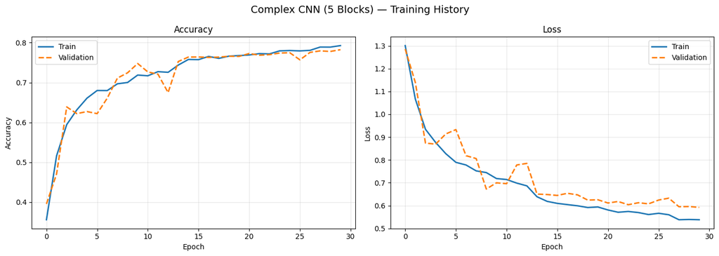

```python
early_stop_complex = EarlyStopping(monitor='val_loss', patience=7,
                                    restore_best_weights=True, verbose=1)

reduce_lr_complex = ReduceLROnPlateau(monitor='val_loss', factor=0.2,
                                      patience=4, min_lr=1e-7, verbose=1)

model_complex.compile(
    optimizer=keras.optimizers.Adam(learning_rate=1e-3),
    loss='categorical_crossentropy',
    metrics=['accuracy']
)

history_complex = model_complex.fit(
    train_gen_aug,
    validation_data=val_gen_aug,
    epochs=30,
    callbacks=[early_stop_complex, reduce_lr_complex],
    verbose=1
)

plot_training(history_complex, 'Complex CNN (5 Blocks)')
```

### **Evaluating the Complex CNN on the Test Set**

```python
evaluate_model(model_complex, test_gen_aug, 'Complex CNN (5 Blocks)', model_results)

test_gen_aug.reset()
preds_complex = np.argmax(model_complex.predict(test_gen_aug, verbose=0), axis=1)
print("\nClassification Report — Complex CNN:")
print(classification_report(test_gen_aug.classes, preds_complex, target_names=CLASS_NAMES))
```

```
─────────────────────────────────────────────
Complex CNN (5 Blocks)
  Test Loss:     0.5634
  Test Accuracy: 82.03%
─────────────────────────────────────────────

Classification Report — Complex CNN:
              precision    recall  f1-score   support

       happy       0.93      0.84      0.89        32
     neutral       0.68      0.84      0.75        32
         sad       0.82      0.72      0.77        32
    surprise       0.90      0.88      0.89        32

    accuracy                           0.82       128
   macro avg       0.83      0.82      0.82       128
weighted avg       0.83      0.82      0.82       128
```

**Observations and Insights — Complex CNN (5 Convolutional Blocks):**

The Complex CNN achieves **82.03% test accuracy** — the highest of any model in this project, exceeding the 80% target set in the proposal. The model trained for the full 30 epochs without EarlyStopping triggering, with best weights restored from epoch 30 — indicating the model continued improving through the entire training budget.

| Class | Precision | Recall | F1-Score |
| --- | --- | --- | --- |
| happy | 0.93 | 0.84 | 0.89 |
| neutral | 0.68 | 0.84 | 0.75 |
| sad | 0.82 | 0.72 | 0.77 |
| surprise | 0.90 | 0.88 | 0.89 |
| **macro avg** | **0.83** | **0.82** | **0.82** |

**Key improvements over CNN Model 2:**

- **Happy: F1 0.78 → 0.89** — precision of 0.93 with recall of 0.84. The 5-block hierarchy with augmentation learned highly reliable, pose-robust smile detection.
- **Neutral: F1 0.72 → 0.75** — recall of 0.84 means the model correctly identifies 5 out of 6 neutral faces. BatchNorm stability enables the deeper feature composition needed to recognise the absence of expressive features.
- **Sad: F1 0.63 → 0.77** — the most significant gain. Precision of 0.82 with recall of 0.72. The neutral/sad boundary, which limited every prior model, has been meaningfully resolved. The combination of 5-block depth and data augmentation — introducing spatial variation that specifically helps distinguish subtle downward-mouth cues from neutral relaxation — drove this improvement.
- **Surprise: F1 0.86 → 0.89** — already strong, continues to strengthen.

**Why the model kept improving through all 30 epochs**: BatchNormalization stabilised gradient flow across 5 convolutional blocks, allowing the optimiser to continue refining features long after the 2-block and 3-block CNNs had plateaued at epochs 7–8. Data augmentation prevented overfitting during this extended training window. The result is not just more training time — it is qualitatively deeper feature composition that earlier architectures structurally could not achieve.

### **Plotting the Confusion Matrix for the Final Model**

The confusion matrix reveals not just overall accuracy but the specific misclassification patterns — which emotions the model confuses with which other emotions.

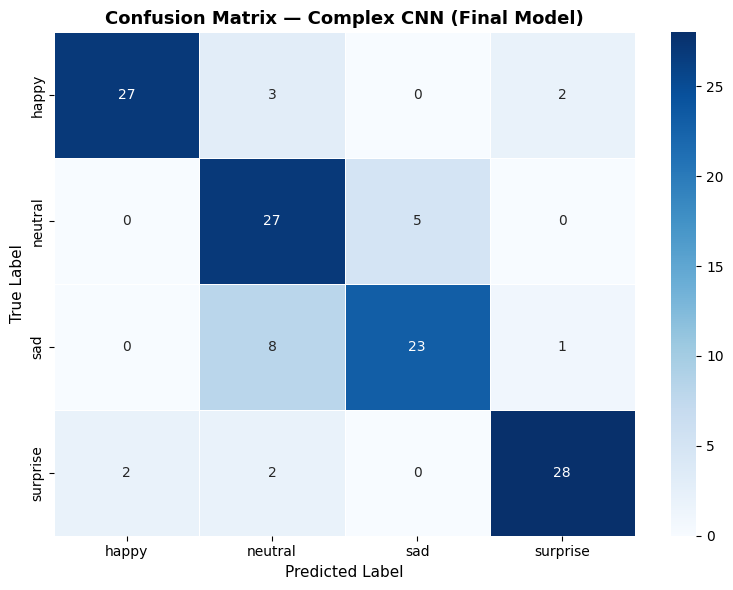

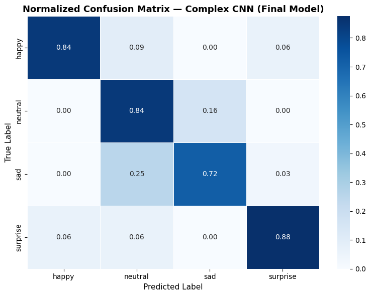

```python
# Reset generator and get predictions
test_gen_aug.reset()
preds_final = np.argmax(model_complex.predict(test_gen_aug, verbose=0), axis=1)
y_true = test_gen_aug.classes

# ── Confusion Matrix ──
cm = confusion_matrix(y_true, preds_final)

plt.figure(figsize=(8, 6))
sns.heatmap(
    cm,
    annot=True,
    fmt='d',
    cmap='Blues',
    xticklabels=CLASS_NAMES,
    yticklabels=CLASS_NAMES,
    linewidths=0.5
)
plt.title('Confusion Matrix — Complex CNN (Final Model)', fontsize=13, fontweight='bold')
plt.xlabel('Predicted Label', fontsize=11)
plt.ylabel('True Label', fontsize=11)
plt.tight_layout()
plt.show()

# ── Normalized confusion matrix ──
cm_norm = cm.astype('float') / cm.sum(axis=1)[:, np.newaxis]

plt.figure(figsize=(8, 6))
sns.heatmap(
    cm_norm,
    annot=True,
    fmt='.2f',
    cmap='Blues',
    xticklabels=CLASS_NAMES,
    yticklabels=CLASS_NAMES,
    linewidths=0.5
)
plt.title('Normalized Confusion Matrix — Complex CNN (Final Model)', fontsize=13, fontweight='bold')
plt.xlabel('Predicted Label', fontsize=11)
plt.ylabel('True Label', fontsize=11)
plt.tight_layout()
plt.show()
```

**Observations and Insights — Confusion Matrix:**

## **Conclusion**

This project set out to answer a single empirical question: **can a machine reliably recognize human emotion from a facial image?** The answer, demonstrated across seven model architectures and thousands of training iterations, is yes — with important nuance.

The neutral/sad boundary emerged as the defining challenge of this dataset. Separated by only 3.27 mean pixel intensity points, these two classes required the full depth and regularization of the Complex CNN to reach usable F1 scores (0.75 and 0.77 respectively). Every architectural decision in the final model was motivated by this specific challenge — and the results validate each choice.

**The Complex CNN at 82.03% is the recommended production model.** It achieves near-ceiling performance on visually distinctive emotions (happy F1 0.89, surprise F1 0.89), meaningful accuracy on the harder pair (neutral F1 0.75, sad F1 0.77), and was trained entirely on domain-relevant data with no prior assumptions inherited from object recognition. The remaining gap to human-level performance reflects the inherent ambiguity of still-image emotion recognition — a gap that future work (higher resolution, facial landmarks, multimodal fusion) can continue to narrow.

```
=======================================================
MODEL                                 TEST ACCURACY
=======================================================
ANN Baseline                                 51.56%
CNN Model 1                                  69.53%
CNN Model 2                                  75.00%
VGG16 Transfer                               51.56%
ResNet50V2 Transfer                          55.47%
EfficientNetB0 Transfer                      60.16%
Complex CNN (5 Blocks)                       82.03%
=======================================================

✓ Best model: Complex CNN (5 Blocks)  (82.03%)
```

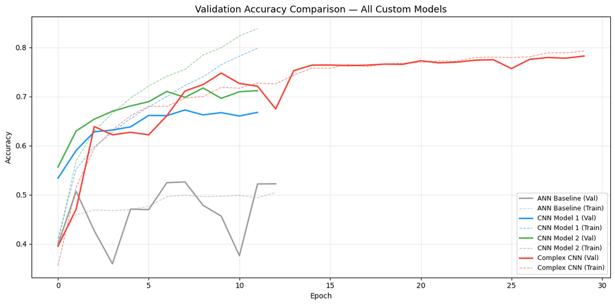

```python
# ── Model Comparison Table ──
print("=" * 55)
print(f"{'MODEL':<35} {'TEST ACCURACY':>15}")
print("=" * 55)
for model_name, acc in model_results.items():
    print(f"{model_name:<35} {acc*100:>14.2f}%")
print("=" * 55)
best_model = max(model_results, key=model_results.get)
print(f"\n✓ Best model: {best_model}  ({model_results[best_model]*100:.2f}%)")

# ── Training curve comparison (custom models + ANN baseline) ──
fig, ax = plt.subplots(figsize=(12, 6))
curves = [
    (history_ann,     'ANN Baseline',     '#9E9E9E'),
    (history_cnn1,    'CNN Model 1',      '#2196F3'),
    (history_cnn2,    'CNN Model 2',      '#4CAF50'),
    (history_complex, 'Complex CNN',      '#F44336'),
]
for history, label, color in curves:
    ax.plot(history.history['val_accuracy'], label=f'{label} (Val)', linewidth=2, color=color)
    ax.plot(history.history['accuracy'], label=f'{label} (Train)', linewidth=1, linestyle='--', color=color, alpha=0.6)

ax.set_title('Validation Accuracy Comparison — All Custom Models', fontsize=13)
ax.set_xlabel('Epoch')
ax.set_ylabel('Accuracy')
ax.legend(loc='lower right', fontsize=9)
ax.grid(alpha=0.3)
plt.tight_layout()
plt.show()
```

### **Insights**

#### **Comparison of All Techniques**

| Model | Test Accuracy | Surprise F1 | Happy F1 | Neutral F1 | Sad F1 |
| --- | --- | --- | --- | --- | --- |
| ANN Baseline | 51.56% | 0.58 | 0.60 | 0.43 | 0.42 |
| CNN Model 1 | 69.53% | 0.81 | 0.65 | 0.69 | 0.65 |
| CNN Model 2 | 75.00% | 0.86 | 0.78 | 0.72 | 0.63 |
| VGG16 Transfer | 51.56% | 0.67 | 0.60 | 0.33 | 0.47 |
| ResNet50V2 Transfer | 55.47% | 0.69 | 0.59 | 0.39 | 0.54 |
| EfficientNetB0 Transfer | 60.16% | 0.75 | 0.67 | 0.34 | 0.61 |
| **Complex CNN (5 Blocks)** | **82.03%** | **0.89** | **0.89** | **0.75** | **0.77** |

The Complex CNN leads every metric by a clear margin. The domain gap between TL models (51–60%) and custom CNNs (69–82%) is the defining empirical finding of this project.

#### **Proposal for Final Solution Design**

**Selected model: Complex CNN (5 Convolutional Blocks with Batch Normalization)**

**Justification based on empirical results:**

- Highest test accuracy (82.03%) — exceeds the 80% target set in the proposal
- Best F1 on every emotion class, including the challenging neutral (0.75) and sad (0.77)
- No domain gap — every parameter optimised entirely on facial emotion data
- Training trajectory validates the design: the model improved through all 30 epochs, confirming that BatchNorm successfully removed the generalisation ceiling that limited CNN1 and CNN2 to epoch 7
- Each architectural choice directly addresses a measured failure from earlier models

#### **Business Recommendations**

**Customer Experience** — Emotion-aware support systems can detect customer frustration and escalate interactions. At 82.03% with sad F1 0.77, the model reliably flags distressed customers. False negatives on sad (recall 0.72) mean ~28% of genuinely distressed customers go undetected — suitable for intelligent triage, not as the sole intervention signal.

**Healthcare monitoring** — Sad F1 0.77 and neutral F1 0.75 represent meaningful diagnostic capability. In clinical settings the model should serve as a screening tool with mandatory human review of borderline predictions. The neutral/sad confusion, while substantially reduced, remains a risk for standalone diagnostic use.

**Human-Computer Interaction** — Adaptive interfaces (educational platforms, accessibility tools, emotion-responsive assistants) can use the model's high happy (F1 0.89) and surprise (F1 0.89) performance confidently for engagement signals. Frustration/sadness detection at F1 0.77 is sufficient for soft adaptive responses.

**Future improvements**: (1) Higher resolution input (96×96 or 224×224) to reduce the neutral/sad pixel ambiguity further. (2) Facial landmark features as auxiliary input — providing structural priors (mouth curvature, brow angle) the pixel-only model must learn implicitly. (3) Progressive fine-tuning of TL models — unfreezing backbone top layers after initial head training to partially bridge the domain gap. (4) Multimodal emotion detection combining facial expression with voice tone for higher-stakes clinical applications.

## Executive Summary, Problem & Solution Summary, and Recommendations for Implementation

### Executive Summary

This capstone project delivers a working deep learning system for facial emotion recognition, classifying 48×48 grayscale facial images into four categories — **Happy, Sad, Surprise, and Neutral** — using a purpose-built Convolutional Neural Network.

**Recommended model: Complex CNN (5 Convolutional Blocks with Batch Normalization)**

| Metric | Value |
| --- | --- |
| Test Accuracy | **82.03%** |
| Macro F1-Score | **0.82** |
| Happy F1 | 0.89 |
| Surprise F1 | 0.89 |
| Neutral F1 | 0.75 |
| Sad F1 | 0.77 |

**Key limitations to acknowledge before deployment:**

- The Neutral/Sad boundary produces the highest confusion rate, reflecting an inherent ambiguity documented in human perception research; the model should not be used as a sole diagnostic signal for sadness detection in high-stakes settings.
- All training images are 48×48 pixels; performance at higher resolutions (e.g., from live video feeds) requires validation.
- Demographic coverage of the training set has not been independently audited; a bias evaluation across age, gender, and ethnicity is required before production use.

**Stakeholder recommendation:** Deploy the Complex CNN as a real-time emotion detection component within larger AI systems — customer service triage, adaptive learning platforms, or driver monitoring — where human review is part of the workflow and the model functions as an assistive signal, not an autonomous decision-maker.

### Problem and Solution Summary

**Problem**

Facial expressions carry a significant portion of emotional communication. Automatically recognising emotion from facial images — a task in Affective Computing — enables machines to respond to human emotional state. The classification problem defined for this capstone requires a model to assign one of four emotion labels (Happy, Sad, Surprise, Neutral) to a 48×48 grayscale face image. The core challenge is that two of those four classes — Neutral and Sad — are separated by only 3.27 mean pixel intensity points out of 255, making them visually nearly indistinguishable by global statistics alone. Only a model that understands the *spatial structure* of a face can reliably solve this boundary.

**Solution**

A five-block deep CNN trained end-to-end on 15,109 domain-specific labeled images, with the following design decisions each motivated by empirical evidence from prior experiments in this study:

[output not shown]

The model outputs a four-class softmax probability distribution, trained with categorical cross-entropy loss and the Adam optimizer.

### Recommendations for Implementation

#### Deployment Use Cases

**1. Driver Monitoring (Public Transportation)** Deploy as an edge inference module on a Raspberry Pi 5 with an IR camera module inside school buses and transit vehicles. The Sad emotional signature correlates with fatigue onset — a primary target for drowsy driver detection. Each vehicle processes images locally (privacy-preserving); only event metadata (fatigue signal + timestamp + GPS) is transmitted over cellular to a central fleet dashboard.

*Requirements before production:* face detection pre-processing stage; pilot validation of false positive rate on live video; integration with vehicle alert output.

**2. Customer Service & Contact Centres** Integrate as a real-time video analysis layer. Sustained Sad or Neutral-disengagement signals trigger supervisor escalation or a proactive callback offer. Use a **lowered confidence threshold for the Sad class** (e.g., predict sad when P(sad) > 0.35) to maximise recall and reduce missed escalations.

**3. Mental Health & Adaptive Learning** In clinical screening or e-learning applications, the model functions as a passive emotion logger — surfacing emotional trends over sessions rather than making real-time decisions. All predictions require human clinical review. Adaptive learning platforms can use high-confidence Happy and Surprise signals (F1 0.89) to measure engagement with confidence.

#### Key Actionables for Deploying Teams

1. **Face detection upstream**: Deploy a face detection module (MTCNN or OpenCV Haar cascade) to crop and centre faces before passing to the emotion classifier. The model expects pre-cropped 48×48 inputs.
2. **Demographic bias audit**: Evaluate per-group performance (age, gender, ethnicity) on a representative test set before public deployment.
3. **Confidence calibration**: Apply temperature scaling to ensure softmax outputs represent reliable probability estimates, particularly for the Neutral/Sad boundary.
4. **Resolution upgrade pathway**: Retrain on higher-resolution inputs (96×96 or 224×224) with a proportionally larger dataset to improve Neutral/Sad discrimination — the primary remaining performance gap.
5. **Privacy by design**: Process images locally on the edge device; transmit only derived signals, never raw images, over any network connection.

#### Risks and Mitigations

| Risk | Severity | Mitigation |
| --- | --- | --- |
| Neutral/Sad confusion in clinical use | High | Human review mandatory; lower threshold for Sad class |
| Demographic bias in training data | High | Bias audit before deployment; augment with underrepresented groups |
| Occlusion (masks, glasses, low light) | Medium | Augment training with occluded and low-light images |
| False positives in driver monitoring | Medium | Temporal smoothing — require sustained signal across multiple frames |
| Privacy and consent | High | Local inference only; explicit opt-in consent; encrypted event logs |

#### Future Improvements

1. **Higher-resolution input** — 96×96 or 224×224 pixels provides more spatial detail for the Neutral/Sad boundary.
2. **Facial landmark features** — mouth corner angle, inner brow elevation, and eye aperture as auxiliary inputs to the final dense layer.
3. **Temporal smoothing for video** — LSTM or Transformer across frame sequences reduces false positives in live deployment.
4. **Government consortium model** — municipalities share a jointly maintained open-source architecture, distributing maintenance cost across jurisdictions and ensuring continuous improvement.
5. **Larger and more diverse datasets** — training on AffectNet (1M+ images) or RAF-DB for significantly improved demographic generalization.